# Jupyter Notebooks

### What is The Jupyter Notebook?

The Jupyter Notebook is an open source web application that is used to create and share documents that contain live code, equations, visualizations, and text. Jupyter Notebook is maintained by the people at Project Jupyter.

The Jupyter Notebook is a powerful tool for interactively developing and presenting data science projects because in this case, a **Notebook** is able to

- integrate code and its output into a single document
- that combines visualizations, narrative text, mathematical equations, and other rich media.

This in-built workflow promotes iterative and rapid development, making Notebooks an increasingly popular choice for modern data science, analysis, and increasingly science at large.

Jupyter is a loose acronym representing Julia, Python, and R. These three programming languages were the first target languages of the Jupyter application. Notebook technology has grown since to support many other programming languages.

### What is The Jupyter Notebook app?

As a server-client application, the Jupyter Notebook app allows you to edit and run your Notebooks via a web browser. The application a) can be executed on a PC without Internet access or b) it can be installed on a remote server making it accessible through the Internet.

There are two main components:

1. A **kernel** is a program that runs and introspects the user’s code. The Jupyter Notebook App has a kernel for Python code, but there are also kernels available for multiple other programming languages.
2. The **dashboard** is specifically designed for managing Jupyter Notebooks by facilitating exploring, editing and creating. And is also used to manage the kernels - identifying which ones are running and allowing for them to be shut down if necessary.

## Installing The Jupyter Notebook

Jupyter Notebooks is packaged with The Anaconda Python Distribution.

Anaconda is the most widely used Python distribution for data science and comes pre-loaded with the most popular libraries and tools. Some of the biggest Python libraries wrapped up in Anaconda include NumPy, pandas and Matplotlib, though the full 1000+ list is exhaustive.

One of the requirements to run The Jupyter Notebook is either Python 2.7, or Python 3.3 or greater. The general recommendation is to use the Anaconda distribution to install both Python and the Jupyter Notebook application.

### Download and install Anaconda

You can download and follow the instructions for the installation of Anaconda [HERE](https://www.anaconda.com/)

### The Pythonic Way: pip

This Python package-management system may be appropriate for more advanced users with Python already installed and who prefer to manage their packages manually.

**On Windows**

`python -m pip install -U pip setuptools`

**On OS X or Linux**

`pip install -U pip setuptools`

**Python 2**

`pip install jupyter`

**Python 3**

`pip3 install jupyter`

For more information about installing packages, visit: [Running Jupyter Notebooks in Docker Containers](https://jupyter-docker-stacks.readthedocs.io/en/latest/using/running.html)

## Starting The Jupyter Notebook Server

It is recommended using the default local Documents folder to store Jupyter Notebooks. Before starting for the first time, create a subfolder: *Notebooks*

Then...

In Windows, Jupyter can be run via the shortcut Anaconda adds to the Start Menu

Or it is also possible to access on any system via the command prompt (or terminal on Unix systems) by entering the command: `jupyter notebook`

Resulting in...

The application opening in the default web browser on the following address: http://localhost:8888

[figure not shown]

## Creating a Jupyter Notebook document

In the Jupyter dashboard...

1. Browse to the Notebooks subfolder
2. Select the `New` labelled drop-down button in the top-right corner of the menu bar

[figure not shown]

1. Select `Python 3` (or version of choice) from the drop-down list

[figure not shown]

In the top left corner of the page, next to the Jupyter logo, is the word: *Untitled* This is the current title for the page and the name of the Jupyter Notebook.

1. Click on the title to activate the in-browser dialog box titled: `Rename Notebook`
2. Type *Hello Jupyter* in the textbox and select `OK`

[figure not shown]

Each Jupyter Notebook is saved as a **.ipynb** file. This is essentially a text file that describes the contents of the Notebook in the format: JSON. Each cell and its contents, including image attachments that have been converted into strings of text, are listed therein along with some metadata.

## Cells

Cells form the body of a Jupyter Notebook.

1. A **code cell** contains code to be executed in the kernel and displays its output directly below. The first cell in a new Jupyter Notebook is always a code cell.
2. A **Markdown cell** contains text formatted using Markdown and displays its output in-place when it is run.

All Jupyter Notebook cells default as code cell when first created/inserted, applying the selected kernel such as Python 3. To change the cell type, whilst in the cell, select the **Cell** drop-down menu. And the select the preferred type from the options presented under *Cell Type*

**Running a cell** means executing the cell’s contents. This is done by selecting the cell and clicking the `Run` button on the toolbar of by using the keyboard shortcut: `Shift` + `Enter` or `Ctrl` + `Enter`

When multiple cells in a Jupyter Notebook are run in order, variables and imports will be shared across the cells where applicable. Making it easier to separate code into logical chunks without the need to reimport libraries nor recreate variables or functions in every cell.

When running cells, their specific border will be turned blue: **command mode**, whereas it will be green during authoring: **edit mode** There is always one active cell highlighted in the Jupyter Notebook with a border colour denoting its current mode.

Also, when a code cell is run, a label with square braces with the word: `In` appear in the left margin of the cell. This is simply short for *Input*.

These square braces will be blank until auto filled with a number. This number indicates that specific cell's index in the order of all of the cells being run. For example, running the first cell at the top of a Jupyter Notebook will result in the square braces being filled with the number: `1` once the instruction has been completely processed. If this same cell is run again, the square braces will update to reflect the number: `2` on completion.

While a code cell is still running, the braces will be filled with an asterisk symbol: `*`

The difference between code and Markdown cells is obvious at a glance as code cells have the Input label reflecting in the left margin and Markdown cells do not.

### Exercise 1

Type as below in the first cell of the new Jupyter Notebook and run the cell. The result should appear directly below the first cell.

```python
print('Hello World!')
```

```
Hello World!
```

### Exercise 2

Type as below in a new cell of the same Jupyter Notebook and run the cell. Identify and discuss the different result.

```python
import time
time.sleep(10)
```

## The Menus

### File menu

Options to create a new Jupyter Notebook or rename or open a pre-existing one. The `Save and Checkpoint` option allows to create checkpoints that can be rolled back to if needed.

### Edit menu

Options to `Cut`, `Copy`, and `Paste` cells. Also, to `Delete`, `Split`, or `Merge` a cell. As well as reorder cells.

Items on this menu will be greyed out if they are not applicable to the cell type of the currently selected cell. For example, a code cell cannot have an image inserted.

### View menu

Options are useful for toggling the visibility of the app header and toolbar, as well as the cell's toolbar. It is also possible to `Toggle Line Numbers` within cells on or off.

### Insert menu

Option for inserting cells above or below the currently selected cell.

### Cell menu

Options to run one cell, a group of cells, or all the cells. As well as change a cell’s type.

There is also the ability to clear the cells' `Current Outputs` or `All Output` on this menu. This is most useful when planning to share the Jupyter Notebook with others so that they may run the cells themselves.

### Kernel menu

Options for working with the kernel that is running in the background. It is possible to `Interupt`, `Restart`or `Reconnect` to or `Shutdown` the kernel. As well as change which kernel the Jupyter Notebook is using. This is most useful if when debugging, it is necessary to work directly with the kernel.

### Widgets menu

Options for saving and clearing widget states. Widgets are JavaScript widgets that can be added to cells to create dynamic content using Python (or another kernel).

### Help menu

Option to learn more about the Jupyter Notebook’s `Keyboard Shortcuts`. There is also a `User Interface Tour`, and much reference material.

## Markdown

Markdown is a lightweight, easy to learn mark-up language for formatting plain text.

Its syntax has a one-to-one correspondence with HTML tags, so some prior knowledge here would be helpful but is not a prerequisite.

### Exercise 3

Recreate the following in a new cell of the same Jupyter Notebook in order to experience a basic understanding of formatting options available in Jupyter Notebook.

````python
# This is a Level 1 Heading
## This is a Level 2 Heading
### This is Level 3 Heading

This is some plain text that forms a paragraph.

Add emphasis via **bold** and __bold__, or *italic* and _italic_

Paragraphs must be separated by an empty line.

* Sometimes we want to include lists.
    + Very
    + Good
        - To
        - Know
* Which can be indented.

1. Lists can also be numbered.
2. For ordered lists.

[It is possible to include hyperlinks](https://www.example.com)

For code that is not actually going to run...

Inline code uses single backticks: `foo()`

and code blocks use triple backticks:
```
bar()
```

or can be indented by 4 spaces:
    foo()

And finally, adding images: ![Alt text](https://www.example.com/image.jpg)
````

## Keyboard Shortcuts

These keyboard shortcuts are for Jupyter version 4.1.0 and Mac OSX. For most shortcuts below, it is possible to replace `Cmd` with `Ctrl` for Windows or Linux.

Make use of the `H` keyboard shortcut in Windows or Linux to confirm the operating system appropriate keyboard shortcuts.

[figure not shown]

And/or make use `Cmd` + `Shift` + `P` to open the command palette in order to search all the available commands.

[figure not shown]

### Command Mode

- `shift` + `enter` run cell, select below
- `ctrl` + `enter` run cell
- `option` + `enter` run cell, insert below
- `A` insert cell above
- `B` insert cell below
- `C` copy cell
- `V` paste cell
- `D` , `D` delete selected cell
- `shift` + `M` merge selected cells, or current cell with cell below if only one cell selected
- `I` , `I` interrupt kernel
- `0` , `0` restart kernel (with dialog)
- `Y` change cell to `code` mode
- `M` change cell to `Markdown` mode (good for documentation)

### Edit Mode

- `cmd` + `click` for multi-cursor editing
- `option` + `scrolling click` for column editing
- `cmd` + `/` toggle comment lines
- `tab` code completion or indent
- `shift` + `tab` tooltip
- `ctrl` + `shift` + `-` split cell

## Extensions

One of the most popular extension sets is called `Jupyter Notebook Extensions` available for download here from [GitHub](https://github.com/ipython-contrib/jupyter_contrib_nbextensions)

This is actually a collection of extensions that is provided by the Jupyter community. It is also possible to search for other Jupyter Notebook extensions on-line.

Most Jupyter Notebook extensions can be installed using Python’s pip tool.

If this install option is not compatible, then use the following command: $ jupyter nbextension install EXTENSION_NAME

After installing, enable the extension by running the following: $ jupyter nbextension enable EXTENSION_NAME

It may be necessary to restart the Jupyter Notebook kernel to see the extension.

There is a meta extension called `Jupyter NbExtensions Configurator` that available to manage other extensions alas available for download here from [GitHub](https://github.com/Jupyter-contrib/jupyter_nbextensions_configurator)

This allows for the enabling and disabling of extensions from within the Jupyter Notebook’s user interface and also shows all the currently installed extensions.

## Snippets menu

This extension adds a customisable drop-down menu to the toolbar after the `Help` menu that allows for easy insertion of code cells with Snippets, boilerplate and examples of code into the current Jupyter Notebook.

Snippets are those pieces of code that may be required from time to time, especially when a) the details may be forgotten, or b) a web search may be too time consuming, or c) consistency needs to be maintained throughout, or d) typing out again seems counter-productive or e) there is a general lack of experience and knowledge.

It can also be most helpful when just starting out with a programming language for ideas on how to how to construct logical order and syntax such as importing a module, defining variables, or calling functions.

The default menu is named `Snippets` and contains sub-menus with Snippets for a few popular Python packages, as well as Python itself, and some Jupyter Notebook Markdown.

For more information and installation instructions, click [HERE](https://jupyter-contrib-nbextensions.readthedocs.io/en/latest/nbextensions/snippets_menu/readme.html)

[figure not shown]

The Snippets are defined in a JSON file in nbextensions/snippets/snippets.json with an example snippet included.

It is possible use `Textexpander` (Mac OSX) or `PhraseExpress` (Windows) to create customised Snippets.

### Example

`;imp` becomes:

```python
from pprint import pprint
```

```python
from __future__ import division

import numpy as np

import pandas as pd

from pandas import Series, DataFrame

from numpy.random import randn

from scipy import stats

import matplotlib as mpl
import matplotlib.pyplot as plt
import seaborn as sns
sns.set_style('whitegrid')

%matplotlib inline

import math

from sklearn.linear_model import LogisticRegression
from sklearn.linear_model import LinearRegression
#from sklearn.cross_validation import train_test_split (Old SKLearn Version)
from sklearn.model_selection import train_test_split

from sklearn import metrics

import statsmodels.api as sm

from pprint import pprint
```

## Sharing Notebooks

Mostly individuals share the end-result of their work, which means sharing non-interactive, pre-rendered versions of the Jupyter Notebook. However, it is also possible to collaborate on Jupyter Notebooks with the aid version control systems such as `Git`.

Recently, it has been noticed that some organisations are advertising a service to run interactive Jupyter Notebooks in the Cloud.

A shared Jupyter Notebook will appear exactly in the same state as was when exported or saved, including the output of any code cells. Therefore, to ensure that a Jupyter Notebook is share-ready, there are a few steps that should be taken before sharing:

1. Select `Cell` > `All Output` > `Clear`
2. Select `Kernel` > `Restart & Run All`
3. Wait for all of the code cells to finish executing and check they did so as was expected

This will ensure that the Jupyter Notebook doesn't contain any intermediary output, has a stale state, and will be executed in order at the time of sharing.

## Exporting Notebooks

The Jupyter Notebook has built-in support for exporting to HTML and PDF as well as several other formats.

All options to export may be found under the `File` menu on the drop-down `Download as`

As many researchers in academic institutions are given some public or internal webspace, Jupyter Notebooks can be an especially convenient way to share results with peers when exported as a HTML file.

There are also some popular methods of sharing **.ipynb** files more directly on the web.

References

- https://www.datacamp.com/community/tutorials/tutorial-jupyter-notebook
- https://realpython.com/jupyter-notebook-introduction/
- https://www.dataquest.io/blog/jupyter-notebook-tutorial/
- http://maxmelnick.com/2016/04/19/python-beginner-tips-and-tricks.html

# Python Data Structures

## Crealing a lit of lists

```python
!head pulsar_stars.csv
```

```python
import csv
```

```python
def csv_to_list(path):
    with open(path) as f:
        reader = csv.reader(f)
        headings = next(reader)
        body = [line for line in reader]
    return headings, body
```

```python
%timeit csv_to_list('data/pulsar_stars.csv')
```

```
32.7 ms &pm; 1.31 ms per loop (mean &pm; std. dev. of 7 runs, 10 loops each)
```

```python
pulsar_headings, pulsar_data = csv_to_list('data/pulsar_stars.csv')
```

```python
pulsar_headings
```

```
[' Mean of the integrated profile',
 ' Standard deviation of the integrated profile',
 ' Excess kurtosis of the integrated profile',
 ' Skewness of the integrated profile',
 ' Mean of the DM-SNR curve',
 ' Standard deviation of the DM-SNR curve',
 ' Excess kurtosis of the DM-SNR curve',
 ' Skewness of the DM-SNR curve',
 'target_class']
```

```python
pulsar_data[:5]
```

```
[['140.5625',
  '55.68378214',
  '-0.234571412',
  '-0.699648398',
  '3.199832776',
  '19.11042633',
  '7.975531794',
  '74.24222492',
  '0'],
 ['102.5078125',
  '58.88243001',
  '0.465318154',
  '-0.515087909',
  '1.677257525',
  '14.86014572',
  '10.57648674',
  '127.3935796',
  '0'],
 ['103.015625',
  '39.34164944',
  '0.323328365',
  '1.051164429',
  '3.121237458',
  '21.74466875',
  '7.735822015',
  '63.17190911',
  '0'],
 ['136.75',
  '57.17844874',
  '-0.068414638',
  '-0.636238369',
  '3.642976589',
  '20.9592803',
  '6.89649891',
  '53.59366067',
  '0'],
 ['88.7265625',
  '40.67222541',
  '0.600866079',
  '1.123491692',
  '1.178929766',
  '11.4687196',
  '14.26957284',
  '252.5673058',
  '0']]
```

How much memory is used

```python
import objgraph
objgraph.show_refs([pulsar_headings], filename='headings-graph.png')
```

[figure not shown]

```python
objgraph.show_refs([pulsar_data], filename='pulsar-data-graph.png')
```

[figure not shown]

```python
objgraph.show_most_common_types()
```

```
list               25301
dict               20423
function           14367
tuple              6124
DFAPlan            5205
weakref            2891
NFAArc             2474
wrapper_descriptor 2197
NFAState           2180
getset_descriptor  1979
```

```python
import sys
sys.getsizeof(pulsar_headings)
```

```
192
```

```python
sys.getsizeof(pulsar_data)
```

```
158200
```

```python
sys.getsizeof(pulsar_headings[0])
```

```
80
```

```python
[sys.getsizeof(item) for item in pulsar_headings]
```

```
[80, 94, 91, 84, 74, 88, 85, 78, 61]
```

```python
sum([sys.getsizeof(item) for item in pulsar_headings])
```

```
735
```

```python
sum([sum([sys.getsizeof(item) for item in row]) for row in pulsar_data])
```

```
9462051
```

### Creating floats

```python
def csv_to_float_list(path):
    with open(path) as f:
        reader = csv.reader(f)
        headings = next(reader)
        body = [[float(item) for item in line] for line in reader]
    return headings, body
```

```python
pulsar_headings, pulsar_data = csv_to_float_list('data/pulsar_stars.csv')
```

```python
sum([sum([sys.getsizeof(item) for item in row]) for row in pulsar_data])
```

```
3865968
```

Getting a single element

```python
pulsar_data[0][0]
```

```
140.5625
```

```python
sys.getsizeof(pulsar_data[0][0])
```

[output not shown]

How could we multiply two columns?

```python
%timeit [row[0] * row[1] for row in pulsar_data]
```

```
1.59 ms &pm; 5.36 &micro;s per loop (mean &pm; std. dev. of 7 runs, 1000 loops each)
```

```python
mul = [row[0] * row[1] for row in pulsar_data]
```

```python
mul[:5]
```

```
[7827.05162705375,
 6035.909095009453,
 4052.8046055924997,
 7819.152865195,
 3608.7067498544534]
```

Losing Your loops From PyCon2015 Jake VanderPlas

```python
def func_python(n):
    d = 0.0
    for i in range(n):
        d += (i % 3 -1) * i
    return d
```

```python
%timeit func_python(10000)
```

```
994 &micro;s &pm; 12.6 &micro;s per loop (mean &pm; std. dev. of 7 runs, 1000 loops each)
```

```python
%load_ext fortranmagic
```

```
The fortranmagic extension is already loaded. To reload it, use:
  %reload_ext fortranmagic
```

```python
%%fortran
subroutine func_fort(n, d)
    integer, intent(in)  :: n
    double precision, intent(out) :: d
    integer :: i
    d = 0
    do i = 0, n - 1
        d = d + (mod(1, 3) -1) * i
    end do
end subroutine func_fort
```

```python
%timeit func_fort(10000)
```

```
97.3 ns &pm; 1.96 ns per loop (mean &pm; std. dev. of 7 runs, 10000000 loops each)
```

```python
from numba import jit

@jit(nopython=True)
def func_numba_python(n):
    d = 0.0
    for i in range(n):
        d += (i % 3 -1) * i
    return d
```

```python
%timeit func_numba_python(10000)
```

```
15 &micro;s &pm; 4.82 &micro;s per loop (mean &pm; std. dev. of 7 runs, 1 loop each)
```

```python
%load_ext cython
```

```python
%%cython -a
def func_cython(n):
    d = 0.0
    for i in range(n):
        d += (i % 3 -1) * i
    return d
```

Generated by Cython 0.29.12

Yellow lines hint at Python interaction.  
Click on a line that starts with a "`+`" to see the C code that Cython generated for it.

```
+1: def func_cython(n):
```

[output not shown]

```
+2:     d = 0.0
```

```
  __Pyx_INCREF(__pyx_float_0_0);
  __pyx_v_d = __pyx_float_0_0;
```

```
+3:     for i in range(n):
```

[output not shown]

```
+4:         d += (i % 3 -1) * i
```

```
    __pyx_t_1 = __Pyx_PyInt_RemainderObjC(__pyx_v_i, __pyx_int_3, 3, 0, 0); if (unlikely(!__pyx_t_1)) __PYX_ERR(0, 4, __pyx_L1_error)
    __Pyx_GOTREF(__pyx_t_1);
    __pyx_t_5 = __Pyx_PyInt_SubtractObjC(__pyx_t_1, __pyx_int_1, 1, 0, 0); if (unlikely(!__pyx_t_5)) __PYX_ERR(0, 4, __pyx_L1_error)
    __Pyx_GOTREF(__pyx_t_5);
    __Pyx_DECREF(__pyx_t_1); __pyx_t_1 = 0;
    __pyx_t_1 = PyNumber_Multiply(__pyx_t_5, __pyx_v_i); if (unlikely(!__pyx_t_1)) __PYX_ERR(0, 4, __pyx_L1_error)
    __Pyx_GOTREF(__pyx_t_1);
    __Pyx_DECREF(__pyx_t_5); __pyx_t_5 = 0;
    __pyx_t_5 = PyNumber_InPlaceAdd(__pyx_v_d, __pyx_t_1); if (unlikely(!__pyx_t_5)) __PYX_ERR(0, 4, __pyx_L1_error)
    __Pyx_GOTREF(__pyx_t_5);
    __Pyx_DECREF(__pyx_t_1); __pyx_t_1 = 0;
    __Pyx_DECREF_SET(__pyx_v_d, __pyx_t_5);
    __pyx_t_5 = 0;
```

```
+5:     return d
```

```
  __Pyx_XDECREF(__pyx_r);
  __Pyx_INCREF(__pyx_v_d);
  __pyx_r = __pyx_v_d;
  goto __pyx_L0;
```

```python
%timeit func_cython(10000)
```

```
740 &micro;s &pm; 20.2 &micro;s per loop (mean &pm; std. dev. of 7 runs, 1000 loops each)
```

```python
%%cython -a
def func_cython_types(n: int) -> float:
    cdef double d = 0.0
    cdef int i
    for i in range(n):
        d += (i % 3 -1) * i
    return d
```

Generated by Cython 0.29.12

Yellow lines hint at Python interaction.  
Click on a line that starts with a "`+`" to see the C code that Cython generated for it.

```
+1: def func_cython_types(n: int) -> float:
```

[output not shown]

```
+2:     cdef double d = 0.0
```

```
  __pyx_v_d = 0.0;
```

```
 3:     cdef int i
```

```
+4:     for i in range(n):
```

```
  __pyx_t_1 = __Pyx_PyInt_As_long(__pyx_v_n); if (unlikely((__pyx_t_1 == (long)-1) && PyErr_Occurred())) __PYX_ERR(0, 4, __pyx_L1_error)
  __pyx_t_2 = __pyx_t_1;
  for (__pyx_t_3 = 0; __pyx_t_3 < __pyx_t_2; __pyx_t_3+=1) {
    __pyx_v_i = __pyx_t_3;
```

```
+5:         d += (i % 3 -1) * i
```

```
    __pyx_v_d = (__pyx_v_d + ((__Pyx_mod_long(__pyx_v_i, 3) - 1) * __pyx_v_i));
  }
```

```
+6:     return d
```

```
  __Pyx_XDECREF(__pyx_r);
  __pyx_t_4 = PyFloat_FromDouble(__pyx_v_d); if (unlikely(!__pyx_t_4)) __PYX_ERR(0, 6, __pyx_L1_error)
  __Pyx_GOTREF(__pyx_t_4);
  __pyx_r = __pyx_t_4;
  __pyx_t_4 = 0;
  goto __pyx_L0;
```

```python
%timeit func_cython_types(10000)
```

```
23.6 &micro;s &pm; 1.19 &micro;s per loop (mean &pm; std. dev. of 7 runs, 10000 loops each)
```

# Monte Carlo Simulation

Random walk simulation from socratica

```python
import random
def random_walk(n):
    x = 0
    y = 0
    for i in range(n):
        step = random.choice(['N','S','E','W'])
        if step == 'N':
            y = y+ 1
        elif step == 'S':
            y = y - 1
        elif step == 'E':
            x = x + 1
        else:
            x = x - 1
    return x, y
```

```python
for i in range(25):
    walk = random_walk(10)
    print(walk, "Distance from home = ", abs(walk[0] + abs(walk[1])))
```

```
(1, 3) Distance from home =  4
(-2, 0) Distance from home =  2
(1, -3) Distance from home =  4
(3, 1) Distance from home =  4
(0, -4) Distance from home =  4
(1, -1) Distance from home =  2
(-3, -1) Distance from home =  2
(-1, -3) Distance from home =  2
(-2, -2) Distance from home =  0
(2, 0) Distance from home =  2
(1, 5) Distance from home =  6
(3, 3) Distance from home =  6
(-2, 0) Distance from home =  2
(-3, -3) Distance from home =  0
(1, 3) Distance from home =  4
(1, -3) Distance from home =  4
(0, 0) Distance from home =  0
(-1, 3) Distance from home =  2
(-1, -3) Distance from home =  2
(0, 0) Distance from home =  0
(2, 2) Distance from home =  4
(4, -2) Distance from home =  6
(3, 3) Distance from home =  6
(4, 0) Distance from home =  4
(-4, -4) Distance from home =  0
```

# Numerical Python (numpy)

## Introduction

Provides

1. An array object of arbitrary homogeneous items
2. Fast mathematical operations over arrays
3. Linear Algebra, Fourier Transforms, Random Number Generation

```python
import numpy as np
```

## Arrays (Matrices)

The core of the `numpy` library is the `array`. An `array` is like a python `list` except that it is homogeneous (all members are same type), the type is always numeric, it has built in support for multiple dimensions, methods for fast computation and *matrix* operations.

```python
A = np.mat('1 2 3; 4 5 6') # np.mat matrix is a subclass of array
```

```python
def print_info(a):
    print('number of elements:', a.size)
    print('number of dimensions:', a.ndim)
    print('shape:', a.shape)
    print('data type:', a.dtype)
    print('strides:', a.strides)
    print('flags:')
    print(a.flags)

print_info(A)
```

```
number of elements: 6
number of dimensions: 2
shape: (2, 3)
data type: int64
strides: (24, 8)
flags:
  C_CONTIGUOUS : True
  F_CONTIGUOUS : False
  OWNDATA : False
  WRITEABLE : True
  ALIGNED : True
  WRITEBACKIFCOPY : False
  UPDATEIFCOPY : False
```

## dtype

The items within the array are homogeneous, that is, they are all of the same type. The type of `numpy` array members are not the standard python numerical types. Hereus a list of the possible `numpy` types.

| Type | Description |
| --- | --- |
| bool | Boolean true or false |
| inti | Platform integer (normally either int32 or int64) |
| int8 | Byte (-128 to 127) |
| int16 | Integer (-32768 to 32767) |
| int32 | Integer (-2 **31 to 2** 31 -1) |
| int64 | Integer (-2 **63 to 2** 63 -1) |
| uint8 | Unsigned integer (0 to 255) |
| uint16 | Unsigned integer (0 to 65535) |
| uint32 | Unsigned integer (0 to 2 ** 32 - 1) |
| uint64 | Unsigned integer (0 to 2 ** 64 - 1) |
| float16 | Half precision float: sign bit, 5 bits exponent, 10 bits mantissa |
| float32 | Single precision float: sign bit, 8 bits exponent, 23 bits mantissa |
| float64, or float | Double precision float: sign bit, 11 bits exponent, 52 bits mantissa |
| complex64, complex128 or complex | Complex number, represented by two 64-bit floats (real and imaginary components) |

## Creating numpy arrays

here are 5 general mechanisms for creating arrays:

1. Conversion from other Python structures (e.g., lists, tuples)
2. Intrinsic numpy array array creation objects (e.g., arange, ones, zeros, etc.)
3. Reading arrays from disk, either from standard or custom formats
4. Creating arrays from raw bytes through the use of strings or buffers
5. Use of special library functions (e.g., random)

This section will not cover means of replicating, joining, or otherwise expanding or mutating existing arrays. Nor will it cover creating object arrays or structured arrays. Both of those are covered in their own sections. Convert from array to list or tuple

### Converting Python array_like Objects to NumPy Arrays

In general, numerical data arranged in an array-like structure in Python can be converted to arrays through the use of the array() function. The most obvious examples are lists and tuples. See the documentation for array() for details for its use. Some objects may support the array-protocol and allow conversion to arrays this way. A simple way to find out if the object can be converted to a numpy array using array() is simply to try it interactively and see if it works! (The Python Way).

Examples:

```python
import numpy as np
x = np.array([2,3,1,0])
x = np.array([2, 3, 1, 0])
x = np.array([[1,2.0],[0,0],(1+1j,3.)]) # note mix of tuple and lists,and types
x = np.array([[ 1.+0.j, 2.+0.j], [ 0.+0.j, 0.+0.j], [ 1.+1.j, 3.+0.j]])
```

### Intrinsic NumPy Array Creation

NumPy has built-in functions for creating arrays from scratch:

`zeros(shape)` will create an array filled with 0 values with the specified shape. The default `dtype` is `float64`.

```python
np.zeros((2, 3))
```

```
array([[0., 0., 0.],
       [0., 0., 0.]])
```

`ones(shape)` will create an array filled with 1 values. It is identical to zeros in all other respects.

An Identity matrix of arbitrary size can be created:

```python
np.identity(4)
```

```
array([[1., 0., 0., 0.],
       [0., 1., 0., 0.],
       [0., 0., 1., 0.],
       [0., 0., 0., 1.]])
```

#### arange

`arange()` will create arrays with regularly incrementing values. Check the docstring for complete information on the various ways it can be used.

```python
help(np.arange)
```

```
Help on built-in function arange in module numpy:

arange(...)
    arange([start,] stop[, step,], dtype=None)

    Return evenly spaced values within a given interval.

    Values are generated within the half-open interval ``[start, stop)``
    (in other words, the interval including `start` but excluding `stop`).
    For integer arguments the function is equivalent to the Python built-in
    `range` function, but returns an ndarray rather than a list.

    When using a non-integer step, such as 0.1, the results will often not
    be consistent.  It is better to use `numpy.linspace` for these cases.

    Parameters
    ----------
    start : number, optional
        Start of interval.  The interval includes this value.  The default
        start value is 0.
    stop : number
        End of interval.  The interval does not include this value, except
        in some cases where `step` is not an integer and floating point
        round-off affects the length of `out`.
    step : number, optional
        Spacing between values.  For any output `out`, this is the distance
        between two adjacent values, ``out[i+1] - out[i]``.  The default
        step size is 1.  If `step` is specified as a position argument,
        `start` must also be given.
    dtype : dtype
        The type of the output array.  If `dtype` is not given, infer the data
        type from the other input arguments.

    Returns
    -------
    arange : ndarray
        Array of evenly spaced values.

        For floating point arguments, the length of the result is
        ``ceil((stop - start)/step)``.  Because of floating point overflow,
        this rule may result in the last element of `out` being greater
        than `stop`.

    See Also
    --------
    linspace : Evenly spaced numbers with careful handling of endpoints.
    ogrid: Arrays of evenly spaced numbers in N-dimensions.
    mgrid: Grid-shaped arrays of evenly spaced numbers in N-dimensions.

    Examples
    --------
    >>> np.arange(3)
    array([0, 1, 2])
    >>> np.arange(3.0)
    array([ 0.,  1.,  2.])
    >>> np.arange(3,7)
    array([3, 4, 5, 6])
    >>> np.arange(3,7,2)
    array([3, 5])
```

Try a few examples will be given below:

```python
np.arange(10)
```

```
array([0, 1, 2, 3, 4, 5, 6, 7, 8, 9])
```

```python
np.arange(2, 10, dtype=float)
```

```
array([2., 3., 4., 5., 6., 7., 8., 9.])
```

```python
np.arange(2, 3, 0.1)
```

```
array([2. , 2.1, 2.2, 2.3, 2.4, 2.5, 2.6, 2.7, 2.8, 2.9])
```

#### linspace

Note that there are some subtleties regarding the last usage that the user should be aware of that are described in the arange docstring.

linspace() will create arrays with a specified number of elements, and spaced equally between the specified beginning and end values.

```python
help(np.linspace)
```

```
Help on function linspace in module numpy:

linspace(start, stop, num=50, endpoint=True, retstep=False, dtype=None, axis=0)
    Return evenly spaced numbers over a specified interval.

    Returns `num` evenly spaced samples, calculated over the
    interval [`start`, `stop`].

    The endpoint of the interval can optionally be excluded.

    .. versionchanged:: 1.16.0
        Non-scalar `start` and `stop` are now supported.

    Parameters
    ----------
    start : array_like
        The starting value of the sequence.
    stop : array_like
        The end value of the sequence, unless `endpoint` is set to False.
        In that case, the sequence consists of all but the last of ``num + 1``
        evenly spaced samples, so that `stop` is excluded.  Note that the step
        size changes when `endpoint` is False.
    num : int, optional
        Number of samples to generate. Default is 50. Must be non-negative.
    endpoint : bool, optional
        If True, `stop` is the last sample. Otherwise, it is not included.
        Default is True.
    retstep : bool, optional
        If True, return (`samples`, `step`), where `step` is the spacing
        between samples.
    dtype : dtype, optional
        The type of the output array.  If `dtype` is not given, infer the data
        type from the other input arguments.

        .. versionadded:: 1.9.0

    axis : int, optional
        The axis in the result to store the samples.  Relevant only if start
        or stop are array-like.  By default (0), the samples will be along a
        new axis inserted at the beginning. Use -1 to get an axis at the end.
```

[output cut: 30 more lines]

```
    >>> np.linspace(2.0, 3.0, num=5, retstep=True)
    (array([ 2.  ,  2.25,  2.5 ,  2.75,  3.  ]), 0.25)

    Graphical illustration:

    >>> import matplotlib.pyplot as plt
    >>> N = 8
    >>> y = np.zeros(N)
    >>> x1 = np.linspace(0, 10, N, endpoint=True)
    >>> x2 = np.linspace(0, 10, N, endpoint=False)
    >>> plt.plot(x1, y, 'o')
    >>> plt.plot(x2, y + 0.5, 'o')
    >>> plt.ylim([-0.5, 1])
    (-0.5, 1)
    >>> plt.show()
```

```python
np.linspace(1., 4., 6)
```

```
array([1. , 1.6, 2.2, 2.8, 3.4, 4. ])
```

```python
np.arange(1.,4.,.6)
```

```
array([1. , 1.6, 2.2, 2.8, 3.4])
```

The advantage of this creation function is that one can guarantee the number of elements and the starting and end point, which arange() generally will not do for arbitrary start, stop, and step values.

#### indices

indices() will create a set of arrays (stacked as a one-higher dimensioned array), one per dimension with each representing variation in that dimension. An example illustrates much better than a verbal description:

```python
np.indices((3,3))
```

```
array([[[0, 0, 0],
        [1, 1, 1],
        [2, 2, 2]],

       [[0, 1, 2],
        [0, 1, 2],
        [0, 1, 2]]])
```

This is particularly useful for evaluating functions of multiple dimensions on a regular grid.

### Reading Arrays From Disk

This is presumably the most common case of large array creation. The details, of course, depend greatly on the format of data on disk and so this section can only give general pointers on how to handle various formats. Standard Binary Formats

Various fields have standard formats for array data. The following lists the ones with known python libraries to read them and return numpy arrays (there may be others for which it is possible to read and convert to numpy arrays so check the last section as well)

- HDF5: h5py
- FITS: Astropy

Examples of formats that cannot be read directly but for which it is not hard to convert are those formats supported by libraries like PIL (able to read and write many image formats such as jpg, png, etc).

**CSV**

Comma Separated Value files (CSV) are widely used (and an export and import option for programs like Excel). There are a number of ways of reading these files in Python. There are CSV functions in Python and functions in pylab (part of matplotlib).

More generic ascii files can be read using the io package in scipy.

The `numpy.loadtxt` function expects by default a `tab` delimited file, to read a `CSV` file we set the delimiter and skip the heading row below.

```python
pulsar_data = np.loadtxt('data/pulsar_stars.csv', skiprows=1, delimiter=',')

pulsar_data[:10]
```

```
array([[ 1.40562500e+02,  5.56837821e+01, -2.34571412e-01,
        -6.99648398e-01,  3.19983278e+00,  1.91104263e+01,
         7.97553179e+00,  7.42422249e+01,  0.00000000e+00],
       [ 1.02507812e+02,  5.88824300e+01,  4.65318154e-01,
        -5.15087909e-01,  1.67725752e+00,  1.48601457e+01,
         1.05764867e+01,  1.27393580e+02,  0.00000000e+00],
       [ 1.03015625e+02,  3.93416494e+01,  3.23328365e-01,
         1.05116443e+00,  3.12123746e+00,  2.17446687e+01,
         7.73582202e+00,  6.31719091e+01,  0.00000000e+00],
       [ 1.36750000e+02,  5.71784487e+01, -6.84146380e-02,
        -6.36238369e-01,  3.64297659e+00,  2.09592803e+01,
         6.89649891e+00,  5.35936607e+01,  0.00000000e+00],
       [ 8.87265625e+01,  4.06722254e+01,  6.00866079e-01,
         1.12349169e+00,  1.17892977e+00,  1.14687196e+01,
         1.42695728e+01,  2.52567306e+02,  0.00000000e+00],
       [ 9.35703125e+01,  4.66981135e+01,  5.31904850e-01,
         4.16721117e-01,  1.63628763e+00,  1.45450743e+01,
         1.06217484e+01,  1.31394004e+02,  0.00000000e+00],
       [ 1.19484375e+02,  4.87650593e+01,  3.14602200e-02,
        -1.12167573e-01,  9.99163880e-01,  9.27961224e+00,
         1.92062302e+01,  4.79756567e+02,  0.00000000e+00],
       [ 1.30382812e+02,  3.98440556e+01, -1.58322759e-01,
         3.89540448e-01,  1.22073579e+00,  1.43789412e+01,
         1.35394560e+01,  1.98236457e+02,  0.00000000e+00],
       [ 1.07250000e+02,  5.26270783e+01,  4.52688025e-01,
         1.70347382e-01,  2.33193980e+00,  1.44868531e+01,
         9.00100444e+00,  1.07972506e+02,  0.00000000e+00],
       [ 1.07257812e+02,  3.94964884e+01,  4.65881961e-01,
         1.16287712e+00,  4.07943144e+00,  2.49804180e+01,
         7.39707995e+00,  5.77847379e+01,  0.00000000e+00]])
```

```python
print_info(pulsar_data)
```

```
number of elements: 161082
number of dimensions: 2
shape: (17898, 9)
data type: float64
strides: (72, 8)
flags:
  C_CONTIGUOUS : True
  F_CONTIGUOUS : False
  OWNDATA : False
  WRITEABLE : True
  ALIGNED : True
  WRITEBACKIFCOPY : False
  UPDATEIFCOPY : False
```

```python
import sys
sys.getsizeof(pulsar_data)
```

```
112
```

```python
import sys
sys.getsizeof(pulsar_data[0,0])
```

```
32
```

```python
sys.getsizeof(pulsar_data.tobytes())
```

```
1288689
```

```python
x, y = pulsar_data.shape
x * y * 32
```

```
5154624
```

Compare with 9462051 of the list of lists approach

## Selection

### Selecting a row

The first row

```python
pulsar_data[0]
```

```
array([140.5625    ,  55.68378214,  -0.23457141,  -0.6996484 ,
         3.19983278,  19.11042633,   7.97553179,  74.24222492,
         0.        ])
```

### A single element

```python
pulsar_data[0,0]
```

```
140.5625
```

```python
pulsar_data[0][0]
```

```
140.5625
```

### Slicing

First five rows

```python
pulsar_data[0:5]
```

```
array([[ 1.40562500e+02,  5.56837821e+01, -2.34571412e-01,
        -6.99648398e-01,  3.19983278e+00,  1.91104263e+01,
         7.97553179e+00,  7.42422249e+01,  0.00000000e+00],
       [ 1.02507812e+02,  5.88824300e+01,  4.65318154e-01,
        -5.15087909e-01,  1.67725752e+00,  1.48601457e+01,
         1.05764867e+01,  1.27393580e+02,  0.00000000e+00],
       [ 1.03015625e+02,  3.93416494e+01,  3.23328365e-01,
         1.05116443e+00,  3.12123746e+00,  2.17446687e+01,
         7.73582202e+00,  6.31719091e+01,  0.00000000e+00],
       [ 1.36750000e+02,  5.71784487e+01, -6.84146380e-02,
        -6.36238369e-01,  3.64297659e+00,  2.09592803e+01,
         6.89649891e+00,  5.35936607e+01,  0.00000000e+00],
       [ 8.87265625e+01,  4.06722254e+01,  6.00866079e-01,
         1.12349169e+00,  1.17892977e+00,  1.14687196e+01,
         1.42695728e+01,  2.52567306e+02,  0.00000000e+00]])
```

Rows 5 and 6 columns 0, 1 and 2.

```python
pulsar_data[5:7,:3]
```

```
array([[9.35703125e+01, 4.66981135e+01, 5.31904850e-01],
       [1.19484375e+02, 4.87650593e+01, 3.14602200e-02]])
```

### Fancy indexing

Rows 1, 20 and 30

```python
pulsar_data[[1,20,30]]
```

```
array([[ 1.02507812e+02,  5.88824300e+01,  4.65318154e-01,
        -5.15087909e-01,  1.67725752e+00,  1.48601457e+01,
         1.05764867e+01,  1.27393580e+02,  0.00000000e+00],
       [ 1.00890625e+02,  5.18903945e+01,  6.27486528e-01,
        -2.64978020e-02,  3.88377926e+00,  2.30452667e+01,
         6.95316763e+00,  5.22794404e+01,  0.00000000e+00],
       [ 1.10109375e+02,  4.13181699e+01,  9.48603980e-02,
         6.83112610e-01,  1.01003344e+00,  1.30262752e+01,
         1.46665108e+01,  2.31204136e+02,  0.00000000e+00]])
```

## Oprations on Arrays

from http://www.scipy-lectures.org/intro/numpy/operations.html

### Elementwise operations

Basic operations

With scalars:

```python
a = np.array([1, 2, 3, 4])
a + 1
```

```
array([2, 3, 4, 5])
```

```python
2**a
```

```
array([ 2,  4,  8, 16])
```

All arithmetic operates elementwise:

```python
b = np.ones(4) + 1
a - b
```

```
array([-1.,  0.,  1.,  2.])
```

```python
a * b
```

```
array([2., 4., 6., 8.])
```

```python
j = np.arange(5)
2**(j + 1) - j
```

```
array([ 2,  3,  6, 13, 28])
```

These operations are of course much faster than if you did them in pure python:

```python
a = np.arange(10000)
%timeit a + 1
```

```
3.91 &micro;s &pm;pm; 69.8 ns per loop (mean &pm;pm; std. dev. of 7 runs, 100000 loops each)
```

```python
l = range(10000)
%timeit [i+1 for i in l]
```

```
566 &micro;s &pm;pm; 13.8 &micro;s per loop (mean &pm;pm; std. dev. of 7 runs, 1000 loops each)
```

Array multiplication is not matrix multiplication:

```python
c = np.ones((3, 3))
c * c                   # NOT matrix multiplication!
```

```
array([[1., 1., 1.],
       [1., 1., 1.],
       [1., 1., 1.]])
```

### Matrix multiplication:

```python
c.dot(c)
```

```
array([[3., 3., 3.],
       [3., 3., 3.],
       [3., 3., 3.]])
```

```python
c @ c
```

```
array([[3., 3., 3.],
       [3., 3., 3.],
       [3., 3., 3.]])
```

**Exercise: Elementwise operations**

- Try simple arithmetic elementwise operations: add even elements with odd elements
- Time them against their pure python counterparts using %timeit.
- Generate:
  - [2**0, 2**1, 2**2, 2**3, 2**4]
  - a_j = 2^(3*j) - j

Other operations

### Comparisons:

```python
a = np.array([1, 2, 3, 4])
b = np.array([4, 2, 2, 4])
a == b
```

```
array([False,  True, False,  True])
```

```python
a > b
```

```
array([False, False,  True, False])
```

Array-wise comparisons:

```python
a = np.array([1, 2, 3, 4])
b = np.array([4, 2, 2, 4])
c = np.array([1, 2, 3, 4])
np.array_equal(a, b)
```

```
False
```

```python
np.array_equal(a, c)
```

```
True
```

Logical operations:

```python
a = np.array([1, 1, 0, 0], dtype=bool)
b = np.array([1, 0, 1, 0], dtype=bool)
np.logical_or(a, b)
```

```
array([ True,  True,  True, False])
```

```python
np.logical_and(a, b)
```

```
array([ True, False, False, False])
```

**Transcendental functions:**

```python
a = np.arange(5)
np.sin(a)
```

```
array([ 0.        ,  0.84147098,  0.90929743,  0.14112001, -0.7568025 ])
```

```python
np.log(a)
```

```
array([      -inf, 0.        , 0.69314718, 1.09861229, 1.38629436])
```

```python
np.exp(a)
```

```
array([ 1.        ,  2.71828183,  7.3890561 , 20.08553692, 54.59815003])
```

Shape mismatches

```python
a = np.arange(4)
a + np.array([1, 2])
```

```
---------------------------------------------------------------------------
ValueError                                Traceback (most recent call last)
<ipython-input-43-659bcd508c9e> in <module>
      1 a = np.arange(4)
----> 2 a + np.array([1, 2])

ValueError: operands could not be broadcast together with shapes (4,) (2,)
```

Broadcasting? We’ll return to that later.

**Transposition:**

```python
a = np.triu(np.ones((3, 3)), 1)   # see help(np.triu)
a
```

```
array([[0., 1., 1.],
       [0., 0., 1.],
       [0., 0., 0.]])
```

```python
a.T
```

```
array([[0., 0., 0.],
       [1., 0., 0.],
       [1., 1., 0.]])
```

The transposition is a view

As a results, the following code is wrong and will not make a matrix symmetric:

```python
a += a.T
```

It will work for small arrays (because of buffering) but fail for large one, in unpredictable ways.

### Basic reductions

Computing sums

```python
x = np.array([1, 2, 3, 4])
np.sum(x)
```

```
10
```

```python
x.sum()
```

```
10
```

[figure not shown]

Sum by rows and by columns:

```python
x = np.array([[1, 1], [2, 2]])
x
```

```
array([[1, 1],
       [2, 2]])
```

```python
x.sum(axis=0)   # columns (first dimension)
```

```
array([3, 3])
```

```python
x[:, 0].sum(), x[:, 1].sum()
```

```
(3, 3)
```

```python
x.sum(axis=1)   # rows (second dimension)
```

```
array([2, 4])
```

```python
x[0, :].sum(), x[1, :].sum()
```

```
(2, 4)
```

### Other reductions

Extrema:

```python
x = np.array([1, 3, 2])
x.min()
```

```
1
```

```python
x.max()
```

```
3
```

```python
x.argmin()  # index of minimum
```

```
0
```

```python
x.argmax()  # index of maximum
```

```
1
```

### Logical operations:

```python
np.all([True, True, False])
```

```
False
```

```python
np.any([True, True, False])
```

```
True
```

**Can be used for array comparisons:**

```python
a = np.zeros((100, 100))
np.any(a != 0)
```

```
False
```

```python
np.all(a == a)
```

```
True
```

```python
a = np.array([1, 2, 3, 2])
b = np.array([2, 2, 3, 2])
c = np.array([6, 4, 4, 5])
```

```python
((a <= b) & (b <= c)).all()
```

```
True
```

### Statistics:

```python
x = np.array([1, 2, 3, 1])
y = np.array([[1, 2, 3], [5, 6, 1]])
x.mean()
```

```
1.75
```

```python
np.median(x)
```

```
1.5
```

```python
np.median(y, axis=-1) # last axis
```

```
array([2., 5.])
```

```python
x.std()          # full population standard dev.
```

```
0.82915619758885
```

**Exercise: Reductions**

- Given there is a sum, what other function might you expect to see?
- What is the difference between sum and cumsum?

Worked Example: data statistics

Data in populations.txt describes the populations of hares and lynxes (and carrots) in northern Canada during 20 years.

You can view the data in an editor, or alternatively in IPython (both shell and notebook):

```python
!head data/populations.txt
```

```
# year	hare	lynx	carrot
1900	30e3	4e3	48300
1901	47.2e3	6.1e3	48200
1902	70.2e3	9.8e3	41500
1903	77.4e3	35.2e3	38200
1904	36.3e3	59.4e3	40600
1905	20.6e3	41.7e3	39800
1906	18.1e3	19e3	38600
1907	21.4e3	13e3	42300
1908	22e3	8.3e3	44500
```

First, load the data into a NumPy array:

```python
data = np.loadtxt('data/populations.txt')
year, hares, lynxes, carrots = data.T  # trick: columns to variables
```

Then plot it:

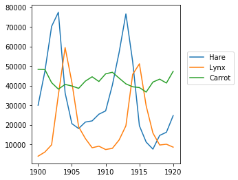

```python
from matplotlib import pyplot as plt
plt.axes([0.2, 0.1, 0.5, 0.8])
plt.plot(year, hares, year, lynxes, year, carrots)
plt.legend(('Hare', 'Lynx', 'Carrot'), loc=(1.05, 0.5))
plt.show()
```

The mean populations over time:

```python
populations = data[:, 1:]
populations.mean(axis=0)
```

```
array([34080.95238095, 20166.66666667, 42400.        ])
```

```python
populations.std(axis=0)
```

```
array([20897.90645809, 16254.59153691,  3322.50622558])
```

Which species has the highest population each year?:

Worked Example: diffusion using a random walk algorithm

[figure not shown]

Let us consider a simple 1D random walk process: at each time step a walker jumps right or left with equal probability.

We are interested in finding the typical distance from the origin of a random walker after t left or right jumps? We are going to simulate many “walkers” to find this law, and we are going to do so using array computing tricks: we are going to create a 2D array with the “stories” (each walker has a story) in one direction, and the time in the other:

[figure not shown]

```python
n_stories = 1000 # number of walkers
t_max = 200      # time during which we follow the walker
```

We randomly choose all the steps 1 or -1 of the walk:

```python
t = np.arange(t_max)
steps = 2 * np.random.randint(0, 1 + 1, (n_stories, t_max)) - 1 # +1 because the high value is exclusive
np.unique(steps) # Verification: all steps are 1 or -1
```

```
array([-1,  1])
```

We build the walks by summing steps along the time:

```python
positions = np.cumsum(steps, axis=1) # axis = 1: dimension of time
sq_distance = positions**2
```

We get the mean in the axis of the stories:

```python
mean_sq_distance = np.mean(sq_distance, axis=0)
```

Plot the results:

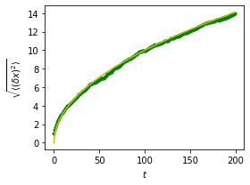

```python
plt.figure(figsize=(4, 3))
plt.plot(t, np.sqrt(mean_sq_distance), 'g.', t, np.sqrt(t), 'y-')
plt.xlabel(r"$t$")
plt.ylabel(r"$\sqrt{\langle (\delta x)^2 \rangle}$")
plt.tight_layout() # provide sufficient space for labels
```

We find a well-known result in physics: the RMS distance grows as the square root of the time!

## Broadcasting

Basic operations on numpy arrays (addition, etc.) are elementwise

This works on arrays of the same size.

- Nevertheless, It’s also possible to do operations on arrays of different
- sizes if NumPy can transform these arrays so that they all have
- the same size: this conversion is called broadcasting.

The image below gives an example of broadcasting:

[figure not shown]

Let’s verify:

```python
a = np.tile(np.arange(0, 40, 10), (3, 1)).T
a
```

```
array([[ 0,  0,  0],
       [10, 10, 10],
       [20, 20, 20],
       [30, 30, 30]])
```

```python
b = np.array([0, 1, 2])
a + b
```

[output not shown]

We have already used broadcasting without knowing it!:

```python
a = np.ones((4, 5))
a[0] = 2  # we assign an array of dimension 0 to an array of dimension 1
a
```

```
array([[2., 2., 2., 2., 2.],
       [1., 1., 1., 1., 1.],
       [1., 1., 1., 1., 1.],
       [1., 1., 1., 1., 1.]])
```

An useful trick:

```python
a = np.arange(0, 40, 10)
a.shape
```

```
(4,)
```

```python
a = a[:, np.newaxis]  # adds a new axis -> 2D array
a.shape
```

```
(4, 1)
```

```python
a
```

```
array([[ 0],
       [10],
       [20],
       [30]])
```

```python
a + b
```

[output not shown]

Broadcasting seems a bit magical, but it is actually quite natural to use it when we want to solve a problem whose output data is an array with more dimensions than input data.

### Worked Example: Broadcasting

Let’s construct an array of distances (in miles) between cities of Route 66: Chicago, Springfield, Saint-Louis, Tulsa, Oklahoma City, Amarillo, Santa Fe, Albuquerque, Flagstaff and Los Angeles.

```python
mileposts = np.array([0, 198, 303, 736, 871, 1175, 1475, 1544,
       1913, 2448])
distance_array = np.abs(mileposts - mileposts[:, np.newaxis])
distance_array
```

```
array([[   0,  198,  303,  736,  871, 1175, 1475, 1544, 1913, 2448],
       [ 198,    0,  105,  538,  673,  977, 1277, 1346, 1715, 2250],
       [ 303,  105,    0,  433,  568,  872, 1172, 1241, 1610, 2145],
       [ 736,  538,  433,    0,  135,  439,  739,  808, 1177, 1712],
       [ 871,  673,  568,  135,    0,  304,  604,  673, 1042, 1577],
       [1175,  977,  872,  439,  304,    0,  300,  369,  738, 1273],
       [1475, 1277, 1172,  739,  604,  300,    0,   69,  438,  973],
       [1544, 1346, 1241,  808,  673,  369,   69,    0,  369,  904],
       [1913, 1715, 1610, 1177, 1042,  738,  438,  369,    0,  535],
       [2448, 2250, 2145, 1712, 1577, 1273,  973,  904,  535,    0]])
```

[figure not shown]

```python
x, y = np.arange(5), np.arange(5)[:, np.newaxis]
distance = np.sqrt(x ** 2 + y ** 2)
distance
```

```
array([[0.        , 1.        , 2.        , 3.        , 4.        ],
       [1.        , 1.41421356, 2.23606798, 3.16227766, 4.12310563],
       [2.        , 2.23606798, 2.82842712, 3.60555128, 4.47213595],
       [3.        , 3.16227766, 3.60555128, 4.24264069, 5.        ],
       [4.        , 4.12310563, 4.47213595, 5.        , 5.65685425]])
```

Or in color:

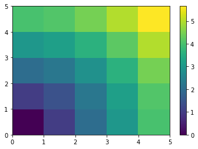

```python
plt.pcolor(distance)
plt.colorbar()
```

Remark : the `numpy.ogrid()` function allows to directly create vectors x and y of the previous example, with two “significant dimensions”:

```python
x, y = np.ogrid[0:5, 0:5]
x, y
```

```
(array([[0],
        [1],
        [2],
        [3],
        [4]]), array([[0, 1, 2, 3, 4]]))
```

```python
x.shape, y.shape
```

```
((5, 1), (1, 5))
```

```python
distance = np.sqrt(x ** 2 + y ** 2)
```

```python
a = np.array([[1, 2, 3], [4, 5, 6]])
a.ravel()
```

```
array([1, 2, 3, 4, 5, 6])
```

```python
a.T
```

```
array([[1, 4],
       [2, 5],
       [3, 6]])
```

```python
a.T.ravel()
```

```
array([1, 4, 2, 5, 3, 6])
```

Higher dimensions: last dimensions ravel out “first”. Reshaping

The inverse operation to flattening:

```python
a.shape
```

```
(2, 3)
```

```python
b = a.ravel()
b = b.reshape((2, 3))
b
```

```
array([[1, 2, 3],
       [4, 5, 6]])
```

Or,

```python
a.reshape((2, -1))    # unspecified (-1) value is inferred
```

```
array([[1, 2, 3],
       [4, 5, 6]])
```

ndarray.reshape may return a view (cf help(np.reshape))), or copy

### Adding a dimension

Indexing with the np.newaxis object allows us to add an axis to an array (you have seen this already above in the broadcasting section):

```python
z = np.array([1, 2, 3])
z
```

```
array([1, 2, 3])
```

```python
z[:, np.newaxis]
```

```
array([[1],
       [2],
       [3]])
```

```python
z[np.newaxis, :]
```

```
array([[1, 2, 3]])
```

### Dimension shuffling

```python
a = np.arange(4*3*2).reshape(4, 3, 2)
a.shape
```

```python
a[0, 2, 1]
```

```python
b = a.transpose(1, 2, 0)
b.shape
```

```python
b[2, 1, 0]
```

Also creates a view:

```python
b[2, 1, 0] = -1
a[0, 2, 1]
```

### Resizing

Size of an array can be changed with ndarray.resize:

```python
a = np.arange(4)
a.resize((8,))
a
```

```
array([0, 1, 2, 3, 0, 0, 0, 0])
```

However, it must not be referred to somewhere else:

```python
b = a
a.resize((4,))
```

```
---------------------------------------------------------------------------
ValueError                                Traceback (most recent call last)
<ipython-input-77-694fdbeb5cf6> in <module>
      1 b = a
----> 2 a.resize((4,))

ValueError: cannot resize an array that references or is referenced
by another array in this way.
Use the np.resize function or refcheck=False
```

**Exercise: Shape manipulations**

- Look at the docstring for reshape, especially the notes section which has some more information about copies and views.
- Use flatten as an alternative to ravel. What is the difference? (Hint: check which one returns a view and which a copy)
- Experiment with transpose for dimension shuffling.

### Sorting data

Sorting along an axis:

```python
a = np.array([[4, 3, 5], [1, 2, 1]])
b = np.sort(a, axis=1)
b
```

```
array([[3, 4, 5],
       [1, 1, 2]])
```

Note: Sorts each row separately!

In-place sort:

```python
a.sort(axis=1)
a
```

```
array([[3, 4, 5],
       [1, 1, 2]])
```

Sorting with fancy indexing:

```python
a = np.array([4, 3, 1, 2])
j = np.argsort(a)
j
```

```
array([2, 3, 1, 0])
```

```python
a[j]
```

```
array([1, 2, 3, 4])
```

```python
a = np.array([[4, 3, 5], [1, 2, 1]])
j = np.argsort(a[:,0],)
j
```

```
array([1, 0])
```

```python
a[j]
```

```
array([[1, 2, 1],
       [4, 3, 5]])
```

### Finding minima and maxima:

```python
a = np.array([4, 3, 1, 2])
j_max = np.argmax(a)
j_min = np.argmin(a)
j_max, j_min
```

```
(0, 2)
```

**Exercise: Sorting**

- Try both in-place and out-of-place sorting.
- Try creating arrays with different dtypes and sorting them.
- Use all or array_equal to check the results.
- Look at np.random.shuffle for a way to create sortable input quicker.
- Combine ravel, sort and reshape.
- Look at the axis keyword for sort and rewrite the previous exercise.

## Standard Linear Algebra operations

The sub-module numpy.linalg implements basic linear algebra, such as solving linear systems, singular value decomposition, etc. However, it is not guaranteed to be compiled using efficient routines, and thus we recommend the use of scipy.linalg, as detailed in section Linear algebra operations: scipy.linalg

**Exercise other operations**

- Look at the help for np.allclose. When might this be useful?
- Look at the help for np.triu and np.tril.

## Solving linear systems

```python
#create the matrices A and b .
A = np.mat("1 -2 1; 0 2 -8; -4 5 9")
print("A", A)
b = np.array([0, 8, -9])
print('b',b)
```

[output not shown]

```python
# Solve this linear system by calling the solve function.
x = np.linalg.solve(A, b)
print ("Solution", x)
```

[output not shown]

```python
#Check whether the solution is correct with the dot function.
print("Check\n", np.dot(A , x))
```

[output not shown]

### Finding eigenvalues and eigenvectors

*Eigenvalues* are scalar solutions to the equation `Ax = ax`, where `A` is a two-dimensional matrix and `x` is a one-dimensional vector. *Eigenvectors* are vectors corresponding to eigenvalues. The `eigvals` function in the `numpy.linalg` package calculates eigenvalues. The `eig` function returns a `tuple` containing eigenvalues and eigenvectors.

```python
#Eigenvals for A
np.linalg.eigvals(A)
```

# NumPy for MATLAB users

Time-stamp: "2007-11-09T16:46:36 vidar" ©2006 Vidar Bronken Gundersen, /mathesaurus.sf.net Permission is granted to copy, distribute and/or modify this document as long as the above attribution is retained.

### Help

| MATLAB/Octave | Python | Description |
| --- | --- | --- |
| `doc` | `help()` | Browse help interactively |
| `help help` [or] `doc doc` | `help` | Help on using help |
| `help plot` | `help(plot)` [or] `?plot` Help for a function |  |
| `help splines` [or] `doc splines` | `help(pylab)` | Help for a toolbox/library package |
| `demo` |  | Demonstration examples |

### Searching available documentation

| MATLAB/Octave | Python | Description |
| --- | --- | --- |
| `lookfor plot` |  | Search help files |
| `help` | `help(); modules [Numeric]` | List available packages |
| `which plot` | `help(plot)` | Locate functions |

### Operators

| MATLAB/Octave | Python | Description |
| --- | --- | --- |
| `help -` |  | Help on operator syntax |

### Arithmetic operators

| Matlab/Octave | Python | Description |
| --- | --- | --- |
| `a .^ b` | `a ** b` | exponent $a^b$ |
| rem(a,b) | `a % b` or `fmod(a,b)` | Remainder |

### Relational operators

| MATLAB/Octave | Python | Description |
| --- | --- | --- |
| `a == b` | `a == b` or `equal(a,b)` | Equal |
| `a < b` | `a < b` or `less(a,b)` | Less than |
| `a > b` | `a > b` or `greater(a,b)` | Greater than |
| `a <= b` | `a <= b` or `less_equal(a,b)` | Less than or equal |
| `a >= b` | `a >= b` or `greater_equal(a,b)` | Greater than or equal |
| `a ~= b` | `a != b` or `not_equal(a,b)` | Not Equal |

### Logical operators

| MATLAB/Octave | Python | Description |
| --- | --- | --- |
| `a && b` | `a and b` | Short-circuit logical AND |
| `a ││ b` | `a or b` | Short-circuit logical OR |
| `a & b` or `and(a,b)` | `logical_and(a,b)` or `a and b` | Element-wise logical AND |
| `a │ b` or `or(a,b)` | `logical_or(a,b)` or `a or b` | Element-wise logical OR |
| `xor(a, b)` | `logical_xor(a,b)` | Logical EXCLUSIVE OR |
| `~a` or `not(a)` | `logical_not(a)` or `not a` | Logical NOT |
| `any(a)` |  | True if any element is nonzero |
| `all(a)` |  | True if all elements are nonzero |

### root and logarithm

| MATLAB/Octave | Python | Description |
| --- | --- | --- |
| `sqrt(a)` | `math.sqrt(a)` | Square root |
| `log(a)` | `math.log(a)` | Logarithm, base $e$ (natural) |
| `log10(a)` | `math.log10(a)` | Logarithm, base 10 |
| `log2(a)` | `math.log(a, 2)` | Logarithm, base 2 (binary) |
| `exp(a)` | `math.exp(a)` | Exponential function |

### Round off

| MATLAB/Octave | Python | Description |
| --- | --- | --- |
| `round(a)` | `around(a)` or `math.round(a)` | Round |
| `ceil(a)` | `ceil(a)` | Round up |
| `floor(a)` | `floor(a)` | Round down |
| `fix(a)` | `fix(a)` | Round towards zero |

### Mathematical constants

| MATLAB/Octave | Python | Description |
| --- | --- | --- |
| `pi` | `math.pi` | $\\pi=3.141592$ |
| `exp(1)` | `math.e` or `math.exp(1)` | $e=2.718281$ |

### Missing values; IEEE-754 floating point status flags

| MATLAB/Octave | Python | Description |
| --- | --- | --- |
| `NaN` | `nan` | Not a Number |
| `Inf` | `inf` | Infinity, $\infty$ |
|  | `plus_inf` | Infinity, $+\infty$ |
|  | `minus_inf` | Infinity, $-\infty$ |
|  | `plus_zero` | Plus zero, $+0$ |
|  | `minus_zero` | Minus zero, $-0$ |

### Complex numbers

| MATLAB/Octave | Python | Description |
| --- | --- | --- |
| `i` | `z = 1j` | Imaginary unit |
| `z = 3+4i` | `z = 3+4j` or `z = complex(3,4)` | A complex number, $3+4i$ |
| `abs(z)` | `abs(3+4j)` | Absolute value (modulus) |
| `real(z)` | `z.real` | Real part |
| `imag(z)` | `z.imag` | Imaginary part |
| `arg(z)` |  | Argument |
| `conj(z)` | `z.conj(); z.conjugate()` | Complex conjugate |

### Trigonometry

| MATLAB/Octave | Python | Description |
| --- | --- | --- |
| `atan(a,b)` | `atan2(b,a)` | Arctangent, $\\arctan(b/a)$ |
|  | `hypot(x,y)` | Hypotenus; Euclidean distance |

### Generate random numbers

| MATLAB/Octave | Python | Description |
| --- | --- | --- |
| `rand(1,10)` | `random.random((10,))` | Uniform distribution |
|  | `random.uniform((10,))`\| |  |
| `2+5*rand(1,10)` | `random.uniform(2,7,(10,))` | Uniform: Numbers between 2 and 7 |
| `rand(6)` | `random.uniform(0,1,(6,6))` | Uniform: 6,6 array |
| `randn(1,10)` | `random.standard_normal((10,))` | Normal distribution |

### Vectors

| MATLAB/Octave | Python | Description |
| --- | --- | --- |
| `a=[2 3 4 5];` | `a=array([2,3,4,5])` | Row vector, $1 \times n$-matrix |
| `adash=[2 3 4 5]';` | `array([2,3,4,5])[:,NewAxis]` | Column vector, $m \times 1$-matrix |
|  | `array([2,3,4,5]).reshape(-1,1)` |  |
|  | `r_[1:10,'c']` |  |

### Matrices

| MATLAB/Octave | Python | Description |
| --- | --- | --- |
| `a = [2 3;4 5]` | `a = array([[2,3],[4,5]])`, `a = mat('2,3;4,5)` | Define a matrix |

### Concatenation (matrices); rbind and cbind

| MATLAB/Octave | Python | Description |
| --- | --- | --- |
| `[a ; b]` | `concatenate((a,b), axis=0)` | Bind rows |
| `[a , b]` | `concatenate((a,b), axis=1)` | Bind columns |
| `[a(:), b(:)]` | `concatenate((a,b), axis=None)` | Concatenate matrices into one vector |
| `[1:4 ; 1:4]` | `concatenate((r_[1:5],r_[1:5])).reshape(2,-1)` | Bind rows (from vectors) |
| `[1:4 ; 1:4]'` |  | Bind columns (from vectors) |

### Array creation

| MATLAB/Octave | Python | Description |
| --- | --- | --- |
| `zeros(3,5)` | `zeros((3,5),Float)` | 0 filled array |
| `ones(3,5)` | `ones((3,5),Float)` | 1 filled array |
| `eye(3)` | `identity(3)` | Identity matrix |
| `diag([4 5 6])` `diag((4,5,6))` | Diagonal |  |
| `magic(3)` | `a = empty((3,3))` | Empty array |

### Reshape and flatten matrices

| MATLAB/Octave | Python | Description |
| --- | --- | --- |
| `reshape(1:6,3,2)';` | `arange(1,7).reshape(2,-1)` | Reshaping (rows first) |
| `reshape(1:6,2,3);` | `arange(1,7).reshape(-1,2).transpose()` | Reshaping (columns first) |
| `a'(:)` | `a.flatten()` [or] | Flatten to vector (by rows, like comics) |
| `a(:)` | `a.flatten(1)` | Flatten to vector (by columns) |
| `vech(a)` |  | Flatten upper triangle (by columns) |

### Shared data (slicing)

| MATLAB/Octave | Python | Description |
| --- | --- | --- |
| `b = a` | `b = a.copy()` | Copy of a |

### Indexing and accessing elements (Python: slicing)

| MATLAB/Octave | Python | Description |
| --- | --- | --- |
| `a = [ 11 12 13 14 ...]` | `a = array([ 11, 12, 13, 14 ],)` | Input array |
| `a(2,3)` | `a[1,2]` | Element 2,3 (row,col) |
| `a(1,:)` | `a[0,]` | First row |
| `a(:,1)` | `a[:,0]` | First column |
| `a([1 3],[1 4]);` | `a.take([0,2]).take([0,3], axis=1)` | Array as indices |
| `a(2:end,:)` | `a[1:,]` | All, except first row |
| `a(end-1:end,:)` | `a[-2:,]` | Last two rows |

### Assignment

| MATLAB/Octave | Python | Description |
| --- | --- | --- |
| `a(:,1) = 99` | `a[:,0] = 99` |  |
| `a(:,1) = [99 98 97]'` | `a[:,0] = array([99,98,97])` |  |
| `a(a>90) = 90;` | `a.clip(min=None, max=90)` | Clipping: Replace all elements over 90 |
| `(a>90).choose(a,90)` | `a.clip(min=2, max=5)` | Clip upper and lower values |

### Transpose and inverse

[output not shown]

### Sum

| MATLAB/Octave | Python | Description |
| --- | --- | --- |
| `sum(a)` | `a.sum(axis=0)` | Sum of each column |
| `sum(a')` | `a.sum(axis=1)` | Sum of each row |
| `sum(sum(a))` | `a.sum()` | Sum of all elements |
|  | `a.trace(offset=0)` | Sum along diagonal |
| `cumsum(a)` | `a.cumsum(axis=0)` | Cumulative sum (columns) |

### Sorting

| MATLAB/Octave | Python | Description |
| --- | --- | --- |
| `a = [ 4 3 2 ; 2 8 6 ; 1 4 7 ]` | `a = array([[4,3,2],[2,8,6],[1,4,7]])` | Example data |
| `sort(a(:))` | `a.ravel().sort()` or | Flat and sorted |
| `sort(a)` | `a.sort(axis=0)` or `msort(a)` | Sort each column |
| `sort(a')'` | `a.sort(axis=1)` | Sort each row |
| `sortrows(a,1)` | `a[a[:,0].argsort(),]` | Sort rows (by first row) |
|  | `a.ravel().argsort()` | Sort, return indices |
|  | `a.argsort(axis=0)` | Sort each column, return indices |
|  | `a.argsort(axis=1)` | Sort each row, return indices |

### Maximum and minimum

| MATLAB/Octave | Python | Description |
| --- | --- | --- |
| `max(a)` | `a.max(0)` or `amax(a [,axis=0])` | max in each column |
| `max(a')` | `a.max(1)` or `amax(a, axis=1)` | max in each row |
| `max(max(a))` | `a.max()` or | max in array |
| `[v i] = max(a)` |  | return indices, i |
| `max(b,c)` | `maximum(b,c)` | pairwise max |
| `cummax(a)` |  |  |
|  | `a.ptp(); a.ptp(0)` | max-to-min range |

### Matrix manipulation

[output not shown]

### Equivalents to "size"

| MATLAB/Octave | Python | Description |
| --- | --- | --- |
| `size(a)` | `a.shape` or `a.getshape()` | Matrix dimensions |
| `size(a,2)` or `length(a)` | `a.shape[1]` or `size(a, axis=1)` | Number of columns |
| `length(a(:))` | `a.size` or `size(a[, axis=None])` | Number of elements |
| `ndims(a)` | `a.ndim` | Number of dimensions |
|  | `a.nbytes` | Number of bytes used in memory |

## Structured Types

### Examples

Using array-scalar type:

```python
np.dtype(np.int16)
```

```
dtype('int16')
```

Structured type, one field name 'f1', containing int16:

```python
np.dtype([('f1', np.int16)])
```

```
dtype([('f1', '<i2')])
```

Structured type, one field named 'f1', in itself containing a structured type with one field:

```python
np.dtype([('f1', [('f1', np.int16)])])
```

```
dtype([('f1', [('f1', '<i2')])])
```

Structured type, two fields: the first field contains an unsigned int, the second an int32:

```python
np.dtype([('f1', np.uint), ('f2', np.int32)])
```

```
dtype([('f1', '<u8'), ('f2', '<i4')])
```

Using array-protocol type strings:

```python
np.dtype([('a','f8'),('b','S10')])
```

```
dtype([('a', '<f8'), ('b', 'S10')])
```

Using comma-separated field formats. The shape is (2,3):

```python
np.dtype("i4, (2,3)f8")
```

```
dtype([('f0', '<i4'), ('f1', '<f8', (2, 3))])
```

Using tuples. `int` is a fixed type, 3 the field's shape. `void` is a flexible type, here of size 10:

```python
np.dtype([('hello',(int,3)),('world',np.void,10)])
```

```
dtype([('hello', '<i8', (3,)), ('world', 'V10')])
```

Subdivide `int16` into 2 `int8`'s, called x and y. 0 and 1 are the offsets in bytes:

```python
np.dtype((np.int16, {'x':(np.int8,0), 'y':(np.int8,1)}))
```

```
dtype((numpy.int16, [('x', 'i1'), ('y', 'i1')]))
```

Using dictionaries. Two fields named 'gender' and 'age':

```python
np.dtype({'names':['gender','age'], 'formats':['S1',np.uint8]})
```

```
dtype([('gender', 'S1'), ('age', 'u1')])
```

Offsets in bytes, here 0 and 25:

```python
np.dtype({'surname':('S25',0),'age':(np.uint8,25)})
```

```
dtype([('surname', 'S25'), ('age', 'u1')])
```

# Visualising Data

In this section we examine some of the features of `matplotlib` a popular library for plotting data.

## Customizing a Plot

### Instantiating defaults

In the script below, we’ve instantiated (and commented) all the figure settings that influence the appearance of the plot.

The settings have been explicitly set to their default values, but now you can interactively play with the values to explore their affect (see Line properties and Line styles below).

```python
import numpy as np
import matplotlib.pyplot as plt
```

```
 <a list of 5 Text yticklabel objects>)
```

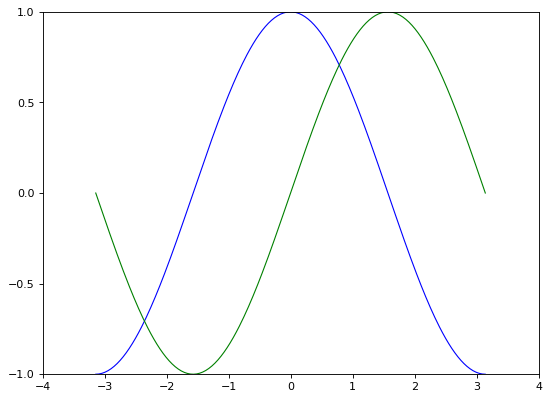

```python
#Create a figure of size 8x6 inches, 80 dots per inch
plt.figure(figsize=(8, 6), dpi=80)

#Create a new subplot from a grid of 1x1
plt.subplot(1, 1, 1)

X = np.linspace(-np.pi, np.pi, 256, endpoint=True)
C, S = np.cos(X), np.sin(X)

# Plot cosine with a blue continuous line of width 1 (pixels)
plt.plot(X, C, color="blue", linewidth=1.0, linestyle="-")

# Plot sine with a green continuous line of width 1 (pixels)
plt.plot(X, S, color="green", linewidth=1.0, linestyle="-")

# Set x limits
plt.xlim(-4.0, 4.0)

# Set x ticks
plt.xticks(np.linspace(-4, 4, 9, endpoint=True))

# Set y limits
plt.ylim(-1.0, 1.0)

# Set y ticks
plt.yticks(np.linspace(-1, 1, 5, endpoint=True))

# Save figure using 72 dots per inch
# plt.savefig("exercise_2.png", dpi=72)
```

```python
# Show result on screen
#plt.show()
```

### Changing colors and line widths

First step, we want to have the cosine in blue and the sine in red and a slighty thicker line for both of them. We’ll also slightly alter the figure size to make it more horizontal.

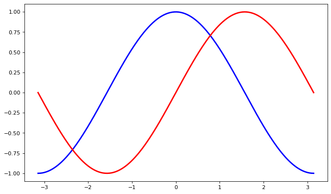

```python
plt.figure(figsize=(10, 6), dpi=80)
plt.plot(X, C, color="blue", linewidth=2.5, linestyle="-")
plt.plot(X, S, color="red",  linewidth=2.5, linestyle="-")
```

### Setting limits

Current limits of the figure are a bit too tight and we want to make some space in order to clearly see all data points.

```
(-1.1, 1.0999165211263138)
```

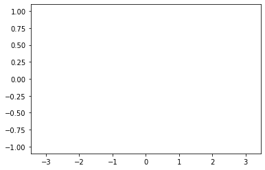

```python
plt.xlim(X.min() * 1.1, X.max() * 1.1)
plt.ylim(C.min() * 1.1, C.max() * 1.1)
```

### Setting ticks

Current ticks are not ideal because they do not show the interesting values (+/-π,+/-π/2) for sine and cosine. We’ll change them such that they show only these values.

```
 <a list of 3 Text yticklabel objects>)
```

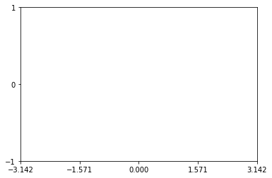

```python
plt.xticks([-np.pi, -np.pi/2, 0, np.pi/2, np.pi])
plt.yticks([-1, 0, +1])
```

### Setting tick labels

Ticks are now properly placed but their label is not very explicit. We could guess that 3.142 is π but it would be better to make it explicit. When we set tick values, we can also provide a corresponding label in the second argument list. Note that we’ll use latex to allow for nice rendering of the label.

```
 <a list of 3 Text yticklabel objects>)
```

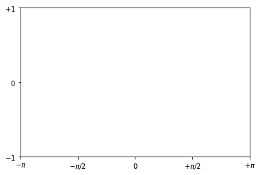

```python
plt.xticks([-np.pi, -np.pi/2, 0, np.pi/2, np.pi],
          [r'$-\pi$', r'$-\pi/2$', r'$0$', r'$+\pi/2$', r'$+\pi$'])

plt.yticks([-1, 0, +1],
          [r'$-1$', r'$0$', r'$+1$'])
```

### Moving spines

Spines are the lines connecting the axis tick marks and noting the boundaries of the data area. They can be placed at arbitrary positions and until now, they were on the border of the axis. We’ll change that since we want to have them in the middle. Since there are four of them (top/bottom/left/right), we’ll discard the top and right by setting their color to none and we’ll move the bottom and left ones to coordinate 0 in data space coordinates.

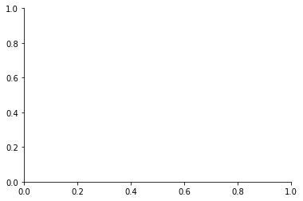

```python
ax = plt.gca()  # gca stands for 'get current axis'
ax.spines['right'].set_color('none')
ax.spines['top'].set_color('none')
ax.xaxis.set_ticks_position('bottom')
ax.spines['bottom'].set_position(('data',0))
ax.yaxis.set_ticks_position('left')
ax.spines['left'].set_position(('data',0))
```

### Adding a legend

Let’s add a legend in the upper left corner. This only requires adding the keyword argument label (that will be used in the legend box) to the plot commands.

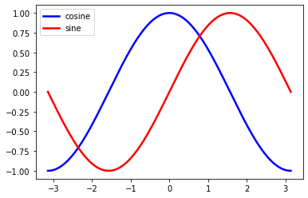

```python
plt.plot(X, C, color="blue", linewidth=2.5, linestyle="-", label="cosine")
plt.plot(X, S, color="red",  linewidth=2.5, linestyle="-", label="sine")

plt.legend(loc='upper left')
```

### Annotate some points

Let’s annotate some interesting points using the annotate command. We chose the 2π/3 value and we want to annotate both the sine and the cosine. We’ll first draw a marker on the curve as well as a straight dotted line. Then, we’ll use the annotate command to display some text with an arrow.

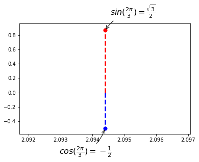

```python
t = 2 * np.pi / 3
plt.plot([t, t], [0, np.cos(t)], color='blue', linewidth=2.5, linestyle="--")
plt.scatter([t, ], [np.cos(t), ], 50, color='blue')

plt.annotate(r'$cos(\frac{2\pi}{3})=-\frac{1}{2}$',
             xy=(t, np.cos(t)), xycoords='data',
             xytext=(-90, -50), textcoords='offset points', fontsize=16,
             arrowprops=dict(arrowstyle="->", connectionstyle="arc3,rad=.2"))

plt.plot([t, t],[0, np.sin(t)], color='red', linewidth=2.5, linestyle="--")
plt.scatter([t, ],[np.sin(t), ], 50, color='red')

plt.annotate(r'$sin(\frac{2\pi}{3})=\frac{\sqrt{3}}{2}$',
             xy=(t, np.sin(t)), xycoords='data',
             xytext=(+10, +30), textcoords='offset points', fontsize=16,
             arrowprops=dict(arrowstyle="->", connectionstyle="arc3,rad=.2"))
```

Devil is in the details The tick labels are now hardly visible because of the blue and red lines. We can make them bigger and we can also adjust their properties such that they’ll be rendered on a semi-transparent white background. This will allow us to see both the data and the labels.

```python
for label in ax.get_xticklabels() + ax.get_yticklabels():
    label.set_fontsize(16)
    label.set_bbox(dict(facecolor='white', edgecolor='None', alpha=0.65))
```

### Putting it all together

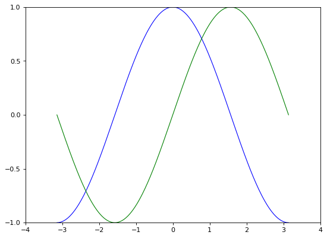

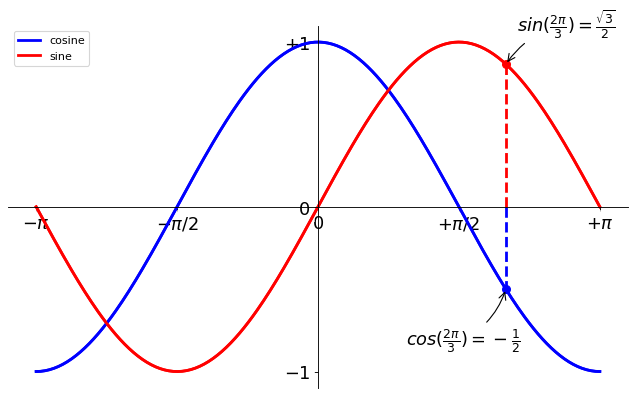

```python
import numpy as np
import matplotlib.pyplot as plt
plt.figure(figsize=(8, 6), dpi=80)
plt.subplot(1, 1, 1)
X = np.linspace(-np.pi, np.pi, 256, endpoint=True)
C, S = np.cos(X), np.sin(X)
plt.plot(X, C, color="blue", linewidth=1.0, linestyle="-")
plt.plot(X, S, color="green", linewidth=1.0, linestyle="-")
plt.xlim(-4.0, 4.0)
plt.xticks(np.linspace(-4, 4, 9, endpoint=True))
plt.ylim(-1.0, 1.0)
plt.yticks(np.linspace(-1, 1, 5, endpoint=True))
plt.figure(figsize=(10, 6), dpi=80)
plt.plot(X, C, color="blue", linewidth=2.5, linestyle="-")
plt.plot(X, S, color="red",  linewidth=2.5, linestyle="-")
plt.xlim(X.min() * 1.1, X.max() * 1.1)
plt.ylim(C.min() * 1.1, C.max() * 1.1)
plt.xticks([-np.pi, -np.pi/2, 0, np.pi/2, np.pi])
plt.yticks([-1, 0, +1])
plt.xticks([-np.pi, -np.pi/2, 0, np.pi/2, np.pi],
          [r'$-\pi$', r'$-\pi/2$', r'$0$', r'$+\pi/2$', r'$+\pi$'])

plt.yticks([-1, 0, +1],
          [r'$-1$', r'$0$', r'$+1$'])
ax = plt.gca()  # gca stands for 'get current axis'
ax.spines['right'].set_color('none')
ax.spines['top'].set_color('none')
ax.xaxis.set_ticks_position('bottom')
ax.spines['bottom'].set_position(('data',0))
ax.yaxis.set_ticks_position('left')
ax.spines['left'].set_position(('data',0))
plt.plot(X, C, color="blue", linewidth=2.5, linestyle="-", label="cosine")
plt.plot(X, S, color="red",  linewidth=2.5, linestyle="-", label="sine")
plt.legend(loc='upper left')
t = 2 * np.pi / 3
plt.plot([t, t], [0, np.cos(t)], color='blue', linewidth=2.5, linestyle="--")
plt.scatter([t, ], [np.cos(t), ], 50, color='blue')

plt.annotate(r'$cos(\frac{2\pi}{3})=-\frac{1}{2}$',
             xy=(t, np.cos(t)), xycoords='data',
             xytext=(-90, -50), textcoords='offset points', fontsize=16,
             arrowprops=dict(arrowstyle="->", connectionstyle="arc3,rad=.2"))

plt.plot([t, t],[0, np.sin(t)], color='red', linewidth=2.5, linestyle="--")
plt.scatter([t, ],[np.sin(t), ], 50, color='red')

plt.annotate(r'$sin(\frac{2\pi}{3})=\frac{\sqrt{3}}{2}$',
             xy=(t, np.sin(t)), xycoords='data',
             xytext=(+10, +30), textcoords='offset points', fontsize=16,
             arrowprops=dict(arrowstyle="->", connectionstyle="arc3,rad=.2"))
for label in ax.get_xticklabels() + ax.get_yticklabels():
    label.set_fontsize(16)
    label.set_bbox(dict(facecolor='white', edgecolor='None', alpha=0.65))
plt.show()
```

## Figures, Subplots, Axes and Ticks

A “figure” in matplotlib means the whole window in the user interface. Within this figure there can be “subplots”.

So far we have used implicit figure and axes creation. This is handy for fast plots. We can have more control over the display using figure, subplot, and axes explicitly. While subplot positions the plots in a regular grid, axes allows free placement within the figure. Both can be useful depending on your intention. We’ve already worked with figures and subplots without explicitly calling them. When we call plot, matplotlib calls `gca()` to get the current axes and gca in turn calls `gcf()` to get the current figure. If there is none it calls `figure()` to make one, strictly speaking, to make a `subplot(111)`. Let’s look at the details.

### Figures

A figure is the windows in the GUI that has “Figure #” as title. Figures are numbered starting from 1 as opposed to the normal Python way starting from 0. This is clearly MATLAB-style. There are several parameters that determine what the figure looks like:

| Argument | Default | Description |
| --- | --- | --- |
| num | 1 | number of figure |
| figsize | figure.figsize | figure size in inches (width, height) |
| dpi | figure.dpi | resolution in dots per inch |
| facecolor | figure.facecolor | color of the drawing background |
| edgecolor | figure.edgecolor | color of edge around the drawing background |
| frameon | True | draw figure frame or not |

The defaults can be specified in the resource file and will be used most of the time. Only the number of the figure is frequently changed.

As with other objects, you can set figure properties also setp or with the set_something methods.

When you work with the GUI you can close a figure by clicking on the x in the upper right corner. But you can close a figure programmatically by calling close. Depending on the argument it closes (1) the current figure (no argument), (2) a specific figure (figure number or figure instance as argument), or (3) all figures ("all" as argument).

```python
plt.close(1)     # Closes figure 1
```

## Graph Types

### Scatter Plots

```
matplotlib.pyplot.scatter(x, y, s=None, c=None, marker=None, cmap=None
                          , norm=None, vmin=None, vmax=None, alpha=None
                          , linewidths=None, verts=None, edgecolors=None
                          , *, plotnonfinite=False, data=None, **kwargs)
```

A scatter plot of y vs x with varying marker size and/or color.

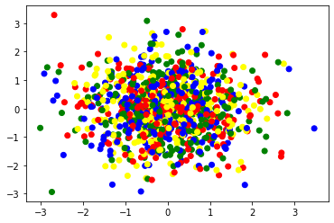

```python
n = 1024
X = np.random.normal(0,1,n)
Y = np.random.normal(0,1,n)

plt.scatter(X,Y, c=["red","green", "blue", "yellow"] * int(1024/4))
```

In the above example the colour of the plot alternates between four values. The parameter `s` can be similarly manipulated to adjust the size of the dots.

### Bar Plots

```
matplotlib.pyplot.bar(x, height, width=0.8, bottom=None, *, align='center', data=None, **kwargs)
```

Make a bar plot.

The bars are positioned at x with the given alignment. Their dimensions are given by width and height. The vertical baseline is bottom (default 0).

Each of x, height, width, and bottom may either be a scalar applying to all bars, or it may be a sequence of length N providing a separate value for each bar.

```
(-1.25, 1.25)
```

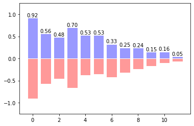

```python
n = 12
X = np.arange(n)
Y1 = (1 - X / float(n)) * np.random.uniform(0.5, 1.0, n)
Y2 = (1 - X / float(n)) * np.random.uniform(0.5, 1.0, n)

plt.bar(X, +Y1, facecolor='#9999ff', edgecolor='white')
plt.bar(X, -Y2, facecolor='#ff9999', edgecolor='white')

for x, y in zip(X, Y1):
    plt.text(x, y , '%.2f' % y, ha='center', va='bottom')

plt.ylim(-1.25, +1.25)
```

### Contour Plots

```
matplotlib.pyplot.contour(*args, data=None, **kwargs)
```

Plot contours.

Call signature:

`contour([X, Y,] Z, [levels], **kwargs)`

`contour` and `contourf` draw contour lines and filled contours, respectively. Except as noted, function signatures and return values are the same for both versions.

```
<a list of 9 text.Text objects>
```

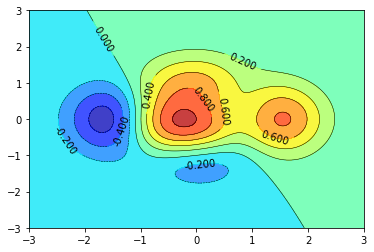

```python
def f(x, y):
    return (1 - x / 2 + x ** 5 + y ** 3) * np.exp(-x ** 2 -y ** 2)

n = 256
x = np.linspace(-3, 3, n)
y = np.linspace(-3, 3, n)
X, Y = np.meshgrid(x, y)

plt.contourf(X, Y, f(X, Y), 8, alpha=.75, cmap='jet')
C = plt.contour(X, Y, f(X, Y), 8, colors='black', linewidths=.5)
plt.clabel(C, C.levels)
```

### Imshow

```
matplotlib.pyplot.imshow(X, cmap=None, norm=None, aspect=None, interpolation=None
                         , alpha=None, vmin=None, vmax=None, origin=None, extent=None
                         , shape=<deprecated parameter>, filternorm=1, filterrad=4.0
                         , imlim=<deprecated parameter>, resample=None, url=None, *, data=None, **kwargs)
```

Display an image, i.e. data on a 2D regular raster.

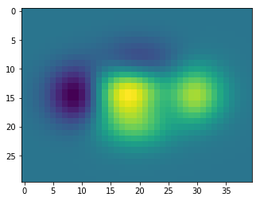

```python
def f(x, y):
    return (1 - x / 2 + x ** 5 + y ** 3) * np.exp(-x ** 2 - y ** 2)

n = 10
x = np.linspace(-3, 3, 4 * n)
y = np.linspace(-3, 3, 3 * n)
X, Y = np.meshgrid(x, y)
plt.imshow(f(X, Y))
```

### Pie Charts

```
matplotlib.pyplot.pie(x, explode=None, labels=None, colors=None, autopct=None
                      , pctdistance=0.6, shadow=False, labeldistance=1.1
                      , startangle=None, radius=None, counterclock=True
                      , wedgeprops=None, textprops=None, center=(0, 0)
                      , frame=False, rotatelabels=False, *, data=None)
```

Plot a pie chart.

Make a pie chart of array x. The fractional area of each wedge is given by x/sum(x). If sum(x) < 1, then the values of x give the fractional area directly and the array will not be normalized. The resulting pie will have an empty wedge of size 1 - sum(x).

The wedges are plotted counterclockwise, by default starting from the x-axis.

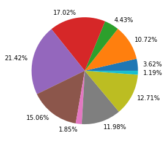

```python
Z = np.random.uniform(0, 1, 10)
labels = ['{:0.2f}%'.format(i) for i in Z/Z.sum()*100]
plt.pie(Z, labels=labels)
plt.show()
```

### Quiver Plots

You need to draw arrows twice.

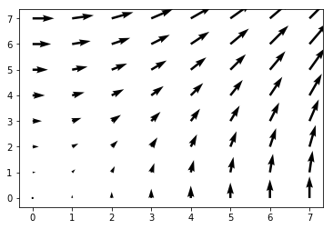

```python
n = 8
X, Y = np.mgrid[0:n, 0:n]
plt.quiver(X, Y)
```

### Grids

```
[]
```

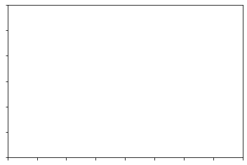

```python
axes = plt.gca()
axes.set_xlim(0, 4)
axes.set_ylim(0, 3)
axes.set_xticklabels([])
axes.set_yticklabels([])
```

### Multi Plots

You can use several subplots with different partition.

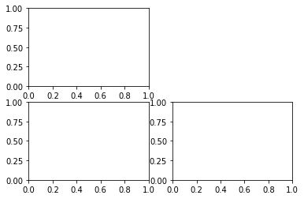

```python
plt.subplot(2, 2, 1)
plt.subplot(2, 2, 3)
plt.subplot(2, 2, 4)
```

You only need to modify the axes line

```python
help(plt.axes)
```

[output not shown]

[output cut: 87 more lines]

```
    .Figure.add_axes
    .pyplot.subplot
    .Figure.add_subplot
    .Figure.subplots
    .pyplot.subplots

    Examples
    --------
    ::

        # Creating a new full window axes
        plt.axes()

        # Creating a new axes with specified dimensions and some kwargs
        plt.axes((left, bottom, width, height), facecolor='w')
```

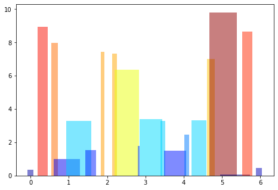

```python
plt.axes([0, 0, 1, 1])

N = 20
theta = np.arange(0., 2 * np.pi, 2 * np.pi / N)
radii = 10 * np.random.rand(N)
width = np.pi / 4 * np.random.rand(N)
bars = plt.bar(theta, radii, width=width, bottom=0.0)

for r, bar in zip(radii, bars):
    bar.set_facecolor(plt.cm.jet(r / 10.))
    bar.set_alpha(0.5)
```

### Histogram

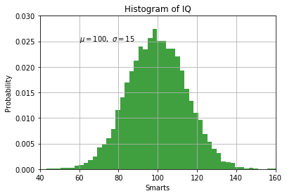

```python
# Fixing random state for reproducibility
np.random.seed(19680801)

mu, sigma = 100, 15
x = mu + sigma * np.random.randn(10000)

# the histogram of the data
n, bins, patches = plt.hist(x, 50, density=True, facecolor='g', alpha=0.75)


plt.xlabel('Smarts')
plt.ylabel('Probability')
plt.title('Histogram of IQ')
plt.text(60, .025, r'$\mu=100,\ \sigma=15$')
plt.axis([40, 160, 0, 0.03])
plt.grid(True)
plt.show()
```

### 3D Plots

You need to use contourf

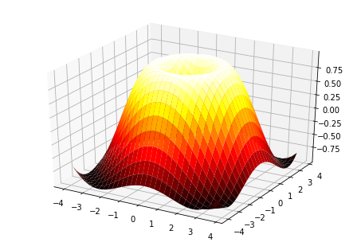

```python
from mpl_toolkits.mplot3d import Axes3D

fig = plt.figure()
ax = Axes3D(fig)
X = np.arange(-4, 4, 0.25)
Y = np.arange(-4, 4, 0.25)
X, Y = np.meshgrid(X, Y)
R = np.sqrt(X**2 + Y**2)
Z = np.sin(R)

ax.plot_surface(X, Y, Z, rstride=1, cstride=1, cmap='hot')
```

# pandas

*Pandas is derived from the term "panel data", an econometrics term for data sets that include observations over multiple time periods for the same individuals. — Wikipedia*

It is said that the pandas package is the most important tool at the disposal of Data Scientists and Analysts working in Python today. It is a Python Library that is highly optimized for performance, with critical code paths written in Cython or C.

The pandas library a central component of the data science toolkit, used in conjunction with other libraries:

1. pandas is built on top of the **NumPy** package
2. data in pandas is often used to feed
- statistical analysis in **SciPy**
- plotting functions from **Matplotlib**
- machine learning algorithms in **Scikit-learn**
1. **Jupyter Notebooks** offer a worthy environment for using pandas to do data exploration and modelling

pandas provides tools for reading and writing data, between in-memory data structures and various formats including:

- CSV and text files
- Microsoft Excel
- SQL databases
- and the fast HDF5 format

### DataFrames and Series

The primary two components of pandas are the Series and Data Frame.

The core feature is the fast and efficient **DataFrame** object, a two-dimensional table structure consisting of rows and columns. Essentially a collection of Series.

Each column is an object known as a **Series**, a one-dimensional labelled array capable of holding any data type (Integers, Strings, floating point numbers, Python objects, etc.). The axis labels are collectively referred to as the Index.

Both DataFrames and Series support several methods for data manipulation with integrated indexing.

DataFrames support:

- sub setting of large data sets
- hierarchical axis indexing provides an intuitive way of working with high-dimensional data in a lower-dimensional data structure
- intelligent label-based slicing
- variability Columns can be inserted and deleted
- high performance merging and joining of data sets
- collection with a powerful group-by engine allowing split-apply-combine operations on data sets

Time series-functionality includes:

- date range generation and frequency conversion
- moving window statistics, moving window linear regressions
- date shifting and lagging

### Module structure

For purposes of this training, we will follow this outline:

1. Install or Import pandas
1. Loading data into DataFrames
   - from a File
   - from a String (Delimited)
   - Using a List
   - Using a Date Range
   - Using other series-like options
1. Operations in DataFrames
   - Visual References (Transposing, Sorting, DataFrame Information and Statistics)
   - Selection by Indexing (by Label, by Position and Boolean Indexing)
   - Setting (Adding, Replacing, Appending, Concatenating and Merging)
   - Missing Data (Reindexing, Subsitituting and Applying)
   - String Methods
   - Summarising (Grouping, Stacking, PivotTables, Time Series and Categoricals)
   - Statistical Functions (Percent change, Covariance and Correlation)
1. Presenting Results
   - Plotting (Linear, Histogram and Box)
   - File I/O (.csv, HDF5, and Excel)
   - Gotchas

```python
# an example of how to ask for help in pandas

# help(pd.Series.loc)
```

## Install or Import pandas

### Install

In the terminal program (for Mac users) or command line (for PC users), use either of the following commands:

`conda install pandas`

OR

`pip install pandas`

### Import

Customarily, we import as follows:

```python
import pandas as pd

import numpy as np

import matplotlib.pyplot as plt
```

## Loading Data into DataFrames

pandas loads data by loading data sets into a DataFrame.

Data sets may be loaded from existing storage such as from a SQL Database, .csv file, or Excel file. pandas I/O API is a set of top level reader functions that generally return a pandas object (for example: `read_csv`). The corresponding writer functions are object methods (for example: `to_csv`).

pandas DataFrames can also be created from a single list or a list of lists, dictionary, and from a list of dictionary etc.

[figure not shown]

### From a File

With .csv files, a single line is required to load data into a DataFrame:

`df = pd.read_csv(file_path, sep=’,’, header=0, index_col=False, names=None)`

- `df` would be replaced by the unique name of the DataFrame

The pandas function: `read_csv` has a plethora of parameters. The most commonly used parameters include:

- `file_path` would be replaced by the required specific path to a file (a str, pathlib.Path, or *py._path.local.LocalPath*), URL (including http, ftp, and S3 locations), or any object with a read() method (such as an open file or StringIO)
- `sep=’,’` indicates that the data being read is separated by commas (,). If this is not the case, specify: `sep =" "` (if separated by a blank space) or `sep='\t'` (if separated by a tab)
- `header=0` indicates that the names of the columns are in the first row in the file. If this is not the case, specify: `header=None`
- `index_col=False` indicates that the first column of the data is not the Index for the DataFrame, If the first column is an Index, specify: `index_col=True`
- `names=None` indicates that the column names are not being specified and will be inferred from the .csv file. If this is not the case, specify: `header=some_number` so that the specified column names are read and loaded correctly. Alternatively, specify the names in order as this value, separated by commas

### From a String (Delimited)

It is also possible to load data using a Delimited String.

This is done by making use of the pandas API compatibility layer: `pandas.compat` and importing the I/O class: `StringIO`

When using the `StringIO` class, ensure imports are according to the Python version in use:

- `from StringIO import StringIO` for Python 2
- `from io import StringIO` for Python 3

**See example below:**

```python
from io import StringIO
gen_load = pd.read_csv(StringIO(
"""
Number,Name,Area Name,Nom kV,Load MW,Gen MW
1,ONE,ESKOM,400,0,90
2,TWO,ESKOM,400,0,90
3,THREE,NAMPOWER,400,180,0
"""), index_col = "Number")
```

Once loaded, the DataFrame can be called by it's name.

**See example below:**

```python
gen_load
```

| Number | Name | Area Name | Nom kV | Load MW | Gen MW |
| --- | --- | --- | --- | --- | --- |
| 1 | ONE | ESKOM | 400 | 0 | 90 |
| 2 | TWO | ESKOM | 400 | 0 | 90 |
| 3 | THREE | NAMPOWER | 400 | 180 | 0 |

```python
import ipywidgets as widgets
import qgrid
gen_load_grid  = qgrid.show_grid(gen_load, show_toolbar=True)

gen_load_grid
```

### Using a List

pandas also facilitates the creation of a Series by passing a list of values.

For this, the pandas function `Series` is called. The result will include a default Integer Index for this Series. This function will also return identification of the datatype (`dtype`) at the end of the DataFrame.

Some frequently used **Series function** parameters include:

- `data` : array-like, dictionary, or scalar value. Contains data stored in Series, separated by a comma, and enclosed with braces `[]`
- `index` : array-like or Index (1d). Values must be hashable and have the same length as data. Non-unique index values are allowed.
- `dtype` : numpy.dtype or None. If None, dtype will be inferred

pandas treats `None` and `NaN` as interchangeable for indicating missing or null values. By default these missing or null values not included in computations. To list a null value, use: `np.nan`

**See example below:**

```python
sFirst = pd.Series([1,3,5,np.nan,6,8])
sFirst
```

```
0    1.0
1    3.0
2    5.0
3    NaN
4    6.0
5    8.0
dtype: float64
```

### Using a Date Range

pandas also facilitates the creation of a DateTime Index by passing a NumPy array.

For this, the pandas function `date_range` is called. The resulting Series is named `DateTimeIndex` by default. This function will also return identification of the datatype (`dtype`) as well as the frequency of the values (`freq`).

Some frequently used *Date Range function* parameters:

- `start` : String or datetime-like, optional. Left bound for generating dates
- `end` : String or datetime-like, optional. Right bound for generating dates
- `periods` : Integer, optional. Number of periods to generate
- `freq` : String or DateOffset, default ‘D’ (calendar daily) String can be updated for all calendar options, and also multiples like 7D or 3M

**See example below:**

```python
dates = pd.date_range('20190101', periods=6)

dates
```

```
DatetimeIndex(['2019-01-01', '2019-01-02', '2019-01-03', '2019-01-04',
               '2019-01-05', '2019-01-06'],
              dtype='datetime64[ns]', freq='D')
```

It is now possible to create a DataFrame with a DateTime Index and labeled columns.

**See example below:**

```python
dfData1 = pd.DataFrame(np.random.randn(6,4), index=dates, columns=list('ABCD'))

dfData1
```

|  | A | B | C | D |
| --- | --- | --- | --- | --- |
| 2019-01-01 | -0.018862 | 0.506884 | 0.002931 | -0.134582 |
| 2019-01-02 | 0.160282 | 1.263459 | -0.304879 | 0.063906 |
| 2019-01-03 | -0.489581 | -0.140495 | -1.804682 | -0.830140 |
| 2019-01-04 | 0.533439 | 1.288184 | 0.830266 | 0.693305 |
| 2019-01-05 | 0.392912 | -0.643530 | 1.619957 | 0.316364 |
| 2019-01-06 | 0.297479 | -0.755912 | 2.391173 | 2.099550 |

### Using other series-like options

pandas also facilitates the creation of a DataFrame by passing a dictionary of objects that can be converted to series-like.

For this, the pandas function `DataFrame` is called.

Some frequently used **DataFrame function** parameters include:

- `data` : numpy ndarray (structured or homogeneous), dictionary, or DataFrame. Dictionary can contain Series, arrays, constants, or list-like objects
- `index` : Index or array-like. Index to use for resulting DataFrame. Will default to RangeIndex if not provided
- `columns` : Index or array-like. Column labels to use for resulting DataFrame. Will default to RangeIndex if not provided
- `dtype` : dtype, default None. Data type to force. Only a single dtype is allowed. If None, it is inferred

**See example below:**

```python
dfData2 = pd.DataFrame({ 'StartValue' : 1.,
                     'StartDate' : pd.Timestamp('20190102'),
                     'EndValue' : pd.Series(1,index=list(range(4)),dtype='float32'),
                     'Activity' : np.array([3] * 4,dtype='int32'),
                     'Action' : pd.Categorical(["test","train","test","train"]),
                     'Response' : 'foo' })
dfData2
```

|  | StartValue | StartDate | EndValue | Activity | Action | Response |
| --- | --- | --- | --- | --- | --- | --- |
| 0 | 1.0 | 2019-01-02 | 1.0 | 3 | test | foo |
| 1 | 1.0 | 2019-01-02 | 1.0 | 3 | train | foo |
| 2 | 1.0 | 2019-01-02 | 1.0 | 3 | test | foo |
| 3 | 1.0 | 2019-01-02 | 1.0 | 3 | train | foo |